# Validación de puntaje de riesgo ISARIC4C para pronóstico de mortalidad en pacientes con COVID-19 evaluados en la admisión al servicio de emergencias en un hospital de referencia nacional en Lima, Perú.

- Enseñar el código
- Esconder el código
- Ver el código

Reporte de Procesamiento de Datos

Autor

Percy Soto Becerra

Fecha de Publicación

4 de octubre de 2022

## 1 Importar datos

## 2 Inspección de datos

**Índice**

- Glimpse
- Frequencies
- Descriptive Statistics
- Data Frame Summary

**Glimpse**

**Código**

```r
data_raw %>%
  glimpse()
```

```
Rows: 1,403
Columns: 195
$ record_id                      <labelled> "1", "2", "4", "5", "6", "7", "8",…
$ redcap_data_access_group       <fct> acceso16, acceso16, acceso16, acceso16,…
$ recolect_id                    <labelled> "garomeroc", "garomeroc", "garomer…
$ fecha_llenado                  <labelled> "2021-12-29 09:51:13", "2021-12-29…
$ doc_tipo_otros                 <labelled> NA, NA, NA, NA, NA, NA, NA, NA, NA…
$ sexo                           <fct> Femenino, Masculino, Masculino, Femenin…
$ edad                           <labelled> 66, 69, 36, 81, 80, 77, 71, 79, 56…
$ sint_resp                      <fct> Sí (historia lo indica), Sí (historia l…
$ dx_covid_pcr                   <fct> Negativo (cuenta con prueba o evaluació…
$ dx_covid_pantig                <fct> No cuenta  con prueba o evaluación, No …
$ dx_covid_prapid                <fct> Negativo (cuenta con prueba o evaluació…
$ dx_covid_clintac               <fct> Positivo (cuenta con prueba o evaluació…
$ emerg_admin                    <fct> Sí, Sí, Sí, Sí, Sí, Sí, Sí, Sí, Sí, Sí,…
```

[output cut: 182 more lines]

**Código**

```r
data_raw %>%
  freq()
```

**Frequencies**

#### data_raw$redcap_data_access_group

**Label:** Data Access Group  
**Type:** Factor

|  | Freq | % Valid | % Valid Cum. | % Total | % Total Cum. |
| --- | --- | --- | --- | --- | --- |
| **acceso01** | 0 | 0.00 | 0.00 | 0.00 | 0.00 |
| **acceso02** | 148 | 10.57 | 10.57 | 10.55 | 10.55 |
| **acceso03** | 99 | 7.07 | 17.64 | 7.06 | 17.61 |
| **acceso04** | 201 | 14.36 | 32.00 | 14.33 | 31.93 |
| **acceso05** | 0 | 0.00 | 32.00 | 0.00 | 31.93 |
| **acceso06** | 66 | 4.71 | 36.71 | 4.70 | 36.64 |
| **acceso07** | 172 | 12.29 | 49.00 | 12.26 | 48.90 |
| **acceso08** | 0 | 0.00 | 49.00 | 0.00 | 48.90 |
| **acceso09** | 0 | 0.00 | 49.00 | 0.00 | 48.90 |
| **acceso10** | 0 | 0.00 | 49.00 | 0.00 | 48.90 |
| **acceso11** | 99 | 7.07 | 56.07 | 7.06 | 55.95 |
| **acceso12** | 157 | 11.21 | 67.29 | 11.19 | 67.14 |
| **acceso13** | 192 | 13.71 | 81.00 | 13.68 | 80.83 |
| **acceso14** | 109 | 7.79 | 88.79 | 7.77 | 88.60 |
| **acceso15** | 0 | 0.00 | 88.79 | 0.00 | 88.60 |
| **acceso16** | 157 | 11.21 | 100.00 | 11.19 | 99.79 |
| **<NA>** | 3 |  |  | 0.21 | 100.00 |
| **Total** | 1403 | 100.00 | 100.00 | 100.00 | 100.00 |

#### data_raw$recolect_id

**Label:** ID médico investigador  
**Type:** Character

|  | Freq | % Valid | % Valid Cum. | % Total | % Total Cum. |
| --- | --- | --- | --- | --- | --- |
| **ajsilva** | 200 | 14.255 | 14.255 | 14.255 | 14.255 |
| **corihuelaj** | 30 | 2.138 | 16.393 | 2.138 | 16.393 |
| **dbguerreroc** | 197 | 14.041 | 30.435 | 14.041 | 30.435 |
| **egcasillah** | 193 | 13.756 | 44.191 | 13.756 | 44.191 |
| **garomeroc** | 260 | 18.532 | 62.723 | 18.532 | 62.723 |
| **hlbojorquezc** | 54 | 3.849 | 66.572 | 3.849 | 66.572 |
| **jcolivaresl** | 1 | 0.071 | 66.643 | 0.071 | 66.643 |
| **jrdljarac** | 18 | 1.283 | 67.926 | 1.283 | 67.926 |
| **magarciaa** | 187 | 13.329 | 81.254 | 13.329 | 81.254 |
| **mlfernandezm** | 34 | 2.423 | 83.678 | 2.423 | 83.678 |
| **nmhidalgos** | 177 | 12.616 | 96.294 | 12.616 | 96.294 |
| **psoteloj** | 28 | 1.996 | 98.289 | 1.996 | 98.289 |
| **vllamocap** | 24 | 1.711 | 100.000 | 1.711 | 100.000 |
| **<NA>** | 0 |  |  | 0.000 | 100.000 |
| **Total** | 1403 | 100.000 | 100.000 | 100.000 | 100.000 |

#### data_raw$doc_tipo_otros

**Label:** Otro tipo de documentos especificar  
**Type:** Logical

|  | Freq | % Valid | % Valid Cum. | % Total | % Total Cum. |
| --- | --- | --- | --- | --- | --- |
| **<NA>** | 1403 |  |  | 100.00 | 100.00 |
| **Total** | 1403 | 0.00 | 100.00 | 100.00 | 100.00 |

#### data_raw$sexo

**Label:** Sexo  
**Type:** Factor

|  | Freq | % Valid | % Valid Cum. | % Total | % Total Cum. |
| --- | --- | --- | --- | --- | --- |
| **Femenino** | 424 | 30.22 | 30.22 | 30.22 | 30.22 |
| **Masculino** | 979 | 69.78 | 100.00 | 69.78 | 100.00 |
| **<NA>** | 0 |  |  | 0.00 | 100.00 |
| **Total** | 1403 | 100.00 | 100.00 | 100.00 | 100.00 |

#### data_raw$sint_resp

**Label:** Al momento del ingreso a Emergencias, ¿El paciente o acompañante de este reportó que el paciente era sintomático respiratorio?  
**Type:** Factor

|  | Freq | % Valid | % Valid Cum. | % Total | % Total Cum. |
| --- | --- | --- | --- | --- | --- |
| **Sí (historia lo indica)** | 1306 | 93.09 | 93.09 | 93.09 | 93.09 |
| **No (historia lo indica)** | 70 | 4.99 | 98.08 | 4.99 | 98.08 |
| **Información no disponible en la historia** | 27 | 1.92 | 100.00 | 1.92 | 100.00 |
| **<NA>** | 0 |  |  | 0.00 | 100.00 |
| **Total** | 1403 | 100.00 | 100.00 | 100.00 | 100.00 |

#### data_raw$dx_covid_pcr

**Label:** Prueba Molecular de RT-PCR  
**Type:** Factor

|  | Freq | % Valid | % Valid Cum. | % Total | % Total Cum. |
| --- | --- | --- | --- | --- | --- |
| **No cuenta con prueba o evaluación** | 1181 | 84.18 | 84.18 | 84.18 | 84.18 |
| **Positivo (cuenta con prueba o evaluación)** | 202 | 14.40 | 98.57 | 14.40 | 98.57 |
| **Negativo (cuenta con prueba o evaluación)** | 20 | 1.43 | 100.00 | 1.43 | 100.00 |
| **<NA>** | 0 |  |  | 0.00 | 100.00 |
| **Total** | 1403 | 100.00 | 100.00 | 100.00 | 100.00 |

#### data_raw$dx_covid_pantig

**Label:** Prueba de Antígeno  
**Type:** Factor

|  | Freq | % Valid | % Valid Cum. | % Total | % Total Cum. |
| --- | --- | --- | --- | --- | --- |
| **No cuenta con prueba o evaluación** | 820 | 58.45 | 58.45 | 58.45 | 58.45 |
| **Positivo (cuenta con prueba o evaluación)** | 442 | 31.50 | 89.95 | 31.50 | 89.95 |
| **Negativo (cuenta con prueba o evaluación)** | 141 | 10.05 | 100.00 | 10.05 | 100.00 |
| **<NA>** | 0 |  |  | 0.00 | 100.00 |
| **Total** | 1403 | 100.00 | 100.00 | 100.00 | 100.00 |

#### data_raw$dx_covid_prapid

**Label:** Prueba Rápida  
**Type:** Factor

|  | Freq | % Valid | % Valid Cum. | % Total | % Total Cum. |
| --- | --- | --- | --- | --- | --- |
| **No cuenta con prueba o evaluación** | 1159 | 82.61 | 82.61 | 82.61 | 82.61 |
| **Positivo (cuenta con prueba o evaluación)** | 142 | 10.12 | 92.73 | 10.12 | 92.73 |
| **Negativo (cuenta con prueba o evaluación)** | 102 | 7.27 | 100.00 | 7.27 | 100.00 |
| **<NA>** | 0 |  |  | 0.00 | 100.00 |
| **Total** | 1403 | 100.00 | 100.00 | 100.00 | 100.00 |

#### data_raw$dx_covid_clintac

**Label:** Criterios clínicos tomográficos  
**Type:** Factor

|  | Freq | % Valid | % Valid Cum. | % Total | % Total Cum. |
| --- | --- | --- | --- | --- | --- |
| **No cuenta con prueba o evaluación** | 191 | 13.61 | 13.61 | 13.61 | 13.61 |
| **Positivo (cuenta con prueba o evaluación)** | 1201 | 85.60 | 99.22 | 85.60 | 99.22 |
| **Negativo (cuenta con prueba o evaluación)** | 11 | 0.78 | 100.00 | 0.78 | 100.00 |
| **<NA>** | 0 |  |  | 0.00 | 100.00 |
| **Total** | 1403 | 100.00 | 100.00 | 100.00 | 100.00 |

#### data_raw$emerg_admin

**Label:** ¿Fue admitido por el Servicio de Emergencias de CELIM COVID-19?  
**Type:** Factor

|  | Freq | % Valid | % Valid Cum. | % Total | % Total Cum. |
| --- | --- | --- | --- | --- | --- |
| **Sí** | 1395 | 99.43 | 99.43 | 99.43 | 99.43 |
| **No** | 8 | 0.57 | 100.00 | 0.57 | 100.00 |
| **<NA>** | 0 |  |  | 0.00 | 100.00 |
| **Total** | 1403 | 100.00 | 100.00 | 100.00 | 100.00 |

#### data_raw$resid_ancian

**Label:** ¿El paciente vive en una residencia para ancianos, asilo, casa de reposo u otro similar?  
**Type:** Factor

|  | Freq | % Valid | % Valid Cum. | % Total | % Total Cum. |
| --- | --- | --- | --- | --- | --- |
| **Sí (historia lo indica)** | 11 | 0.78 | 0.78 | 0.78 | 0.78 |
| **No (historia lo indica o se infiere de la historia)** | 1312 | 93.51 | 94.30 | 93.51 | 94.30 |
| **Información no disponible en la historia** | 80 | 5.70 | 100.00 | 5.70 | 100.00 |
| **<NA>** | 0 |  |  | 0.00 | 100.00 |
| **Total** | 1403 | 100.00 | 100.00 | 100.00 | 100.00 |

#### data_raw$elegibilidad

**Label:** Elegibilidad  
**Type:** Integer

|  | Freq | % Valid | % Valid Cum. | % Total | % Total Cum. |
| --- | --- | --- | --- | --- | --- |
| **1** | 7 | 0.50 | 0.50 | 0.50 | 0.50 |
| **2** | 68 | 4.85 | 5.35 | 4.85 | 5.35 |
| **3** | 1328 | 94.65 | 100.00 | 94.65 | 100.00 |
| **<NA>** | 0 |  |  | 0.00 | 100.00 |
| **Total** | 1403 | 100.00 | 100.00 | 100.00 | 100.00 |

#### data_raw$previo_covid

**Label:** Indicar si historia refiere que paciente tuvo COVID-19 o infección por SARS-CoV-2 previamente al cuadro actual  
**Type:** Factor

|  | Freq | % Valid | % Valid Cum. | % Total | % Total Cum. |
| --- | --- | --- | --- | --- | --- |
| **Sí (historia lo indica)** | 32 | 2.41 | 2.41 | 2.28 | 2.28 |
| **No (historia lo indica)** | 1032 | 77.71 | 80.12 | 73.56 | 75.84 |
| **Información no disponible en la historia** | 264 | 19.88 | 100.00 | 18.82 | 94.65 |
| **<NA>** | 75 |  |  | 5.35 | 100.00 |
| **Total** | 1403 | 100.00 | 100.00 | 100.00 | 100.00 |

#### data_raw$vacuna

**Label:** Indicar si historia clínica refiere que paciente fue vacunado contra el COVID-19  
**Type:** Factor

|  | Freq | % Valid | % Valid Cum. | % Total | % Total Cum. |
| --- | --- | --- | --- | --- | --- |
| **Sí (historia lo indica)** | 12 | 0.90 | 0.90 | 0.86 | 0.86 |
| **No (historia lo indica)** | 975 | 73.42 | 74.32 | 69.49 | 70.35 |
| **Información no disponible en la historia** | 341 | 25.68 | 100.00 | 24.31 | 94.65 |
| **<NA>** | 75 |  |  | 5.35 | 100.00 |
| **Total** | 1403 | 100.00 | 100.00 | 100.00 | 100.00 |

#### data_raw$sint_confusion

**Label:** Confusión  
**Type:** Factor

|  | Freq | % Valid | % Valid Cum. | % Total | % Total Cum. |
| --- | --- | --- | --- | --- | --- |
| **Información no disponible en la historia** | 251 | 18.90 | 18.90 | 17.89 | 17.89 |
| **Sí (historia lo indica)** | 63 | 4.74 | 23.64 | 4.49 | 22.38 |
| **No (historia lo indica)** | 1014 | 76.36 | 100.00 | 72.27 | 94.65 |
| **<NA>** | 75 |  |  | 5.35 | 100.00 |
| **Total** | 1403 | 100.00 | 100.00 | 100.00 | 100.00 |

#### data_raw$sint_disnea

**Label:** Disnea  
**Type:** Factor

|  | Freq | % Valid | % Valid Cum. | % Total | % Total Cum. |
| --- | --- | --- | --- | --- | --- |
| **Información no disponible en la historia** | 45 | 3.39 | 3.39 | 3.21 | 3.21 |
| **Sí (historia lo indica)** | 1194 | 89.91 | 93.30 | 85.10 | 88.31 |
| **No (historia lo indica)** | 89 | 6.70 | 100.00 | 6.34 | 94.65 |
| **<NA>** | 75 |  |  | 5.35 | 100.00 |
| **Total** | 1403 | 100.00 | 100.00 | 100.00 | 100.00 |

#### data_raw$sint_fiebre

**Label:** Fiebre  
**Type:** Factor

|  | Freq | % Valid | % Valid Cum. | % Total | % Total Cum. |
| --- | --- | --- | --- | --- | --- |
| **Información no disponible en la historia** | 159 | 11.97 | 11.97 | 11.33 | 11.33 |
| **Sí (historia lo indica)** | 744 | 56.02 | 68.00 | 53.03 | 64.36 |
| **No (historia lo indica)** | 425 | 32.00 | 100.00 | 30.29 | 94.65 |
| **<NA>** | 75 |  |  | 5.35 | 100.00 |
| **Total** | 1403 | 100.00 | 100.00 | 100.00 | 100.00 |

#### data_raw$sint_fatiga

**Label:** Fatiga  
**Type:** Factor

|  | Freq | % Valid | % Valid Cum. | % Total | % Total Cum. |
| --- | --- | --- | --- | --- | --- |
| **Información no disponible en la historia** | 228 | 17.17 | 17.17 | 16.25 | 16.25 |
| **Sí (historia lo indica)** | 194 | 14.61 | 31.78 | 13.83 | 30.08 |
| **No (historia lo indica)** | 906 | 68.22 | 100.00 | 64.58 | 94.65 |
| **<NA>** | 75 |  |  | 5.35 | 100.00 |
| **Total** | 1403 | 100.00 | 100.00 | 100.00 | 100.00 |

#### data_raw$sint_mialgia

**Label:** Mialgia  
**Type:** Factor

|  | Freq | % Valid | % Valid Cum. | % Total | % Total Cum. |
| --- | --- | --- | --- | --- | --- |
| **Información no disponible en la historia** | 301 | 22.67 | 22.67 | 21.45 | 21.45 |
| **Sí (historia lo indica)** | 71 | 5.35 | 28.01 | 5.06 | 26.51 |
| **No (historia lo indica)** | 956 | 71.99 | 100.00 | 68.14 | 94.65 |
| **<NA>** | 75 |  |  | 5.35 | 100.00 |
| **Total** | 1403 | 100.00 | 100.00 | 100.00 | 100.00 |

#### data_raw$sint_artralgia

**Label:** Artralgia  
**Type:** Factor

|  | Freq | % Valid | % Valid Cum. | % Total | % Total Cum. |
| --- | --- | --- | --- | --- | --- |
| **Información no disponible en la historia** | 312 | 23.49 | 23.49 | 22.24 | 22.24 |
| **Sí (historia lo indica)** | 37 | 2.79 | 26.28 | 2.64 | 24.88 |
| **No (historia lo indica)** | 979 | 73.72 | 100.00 | 69.78 | 94.65 |
| **<NA>** | 75 |  |  | 5.35 | 100.00 |
| **Total** | 1403 | 100.00 | 100.00 | 100.00 | 100.00 |

#### data_raw$sint_rash

**Label:** Rash  
**Type:** Factor

|  | Freq | % Valid | % Valid Cum. | % Total | % Total Cum. |
| --- | --- | --- | --- | --- | --- |
| **Información no disponible en la historia** | 344 | 25.90 | 25.90 | 24.52 | 24.52 |
| **Sí (historia lo indica)** | 4 | 0.30 | 26.20 | 0.29 | 24.80 |
| **No (historia lo indica)** | 980 | 73.80 | 100.00 | 69.85 | 94.65 |
| **<NA>** | 75 |  |  | 5.35 | 100.00 |
| **Total** | 1403 | 100.00 | 100.00 | 100.00 | 100.00 |

#### data_raw$sint_tosseca

**Label:** Tos seca  
**Type:** Factor

|  | Freq | % Valid | % Valid Cum. | % Total | % Total Cum. |
| --- | --- | --- | --- | --- | --- |
| **Información no disponible en la historia** | 255 | 19.20 | 19.20 | 18.18 | 18.18 |
| **Sí (historia lo indica)** | 227 | 17.09 | 36.30 | 16.18 | 34.35 |
| **No (historia lo indica)** | 846 | 63.70 | 100.00 | 60.30 | 94.65 |
| **<NA>** | 75 |  |  | 5.35 | 100.00 |
| **Total** | 1403 | 100.00 | 100.00 | 100.00 | 100.00 |

#### data_raw$sint_tosprod

**Label:** Tos productiva  
**Type:** Factor

|  | Freq | % Valid | % Valid Cum. | % Total | % Total Cum. |
| --- | --- | --- | --- | --- | --- |
| **Información no disponible en la historia** | 281 | 21.16 | 21.16 | 20.03 | 20.03 |
| **Sí (historia lo indica)** | 96 | 7.23 | 28.39 | 6.84 | 26.87 |
| **No (historia lo indica)** | 951 | 71.61 | 100.00 | 67.78 | 94.65 |
| **<NA>** | 75 |  |  | 5.35 | 100.00 |
| **Total** | 1403 | 100.00 | 100.00 | 100.00 | 100.00 |

#### data_raw$sint_tosnodef

**Label:** Tos (no definido tipo)  
**Type:** Factor

|  | Freq | % Valid | % Valid Cum. | % Total | % Total Cum. |
| --- | --- | --- | --- | --- | --- |
| **Información no disponible en la historia** | 229 | 17.24 | 17.24 | 16.32 | 16.32 |
| **Sí (historia lo indica)** | 442 | 33.28 | 50.53 | 31.50 | 47.83 |
| **No (historia lo indica)** | 657 | 49.47 | 100.00 | 46.83 | 94.65 |
| **<NA>** | 75 |  |  | 5.35 | 100.00 |
| **Total** | 1403 | 100.00 | 100.00 | 100.00 | 100.00 |

#### data_raw$sint_dolortox

**Label:** Dolor de tórax  
**Type:** Factor

|  | Freq | % Valid | % Valid Cum. | % Total | % Total Cum. |
| --- | --- | --- | --- | --- | --- |
| **Información no disponible en la historia** | 314 | 23.64 | 23.64 | 22.38 | 22.38 |
| **Sí (historia lo indica)** | 116 | 8.73 | 32.38 | 8.27 | 30.65 |
| **No (historia lo indica)** | 898 | 67.62 | 100.00 | 64.01 | 94.65 |
| **<NA>** | 75 |  |  | 5.35 | 100.00 |
| **Total** | 1403 | 100.00 | 100.00 | 100.00 | 100.00 |

#### data_raw$sint_hemopt

**Label:** Hemoptisis  
**Type:** Factor

|  | Freq | % Valid | % Valid Cum. | % Total | % Total Cum. |
| --- | --- | --- | --- | --- | --- |
| **Información no disponible en la historia** | 341 | 25.68 | 25.68 | 24.31 | 24.31 |
| **Sí (historia lo indica)** | 8 | 0.60 | 26.28 | 0.57 | 24.88 |
| **No (historia lo indica)** | 979 | 73.72 | 100.00 | 69.78 | 94.65 |
| **<NA>** | 75 |  |  | 5.35 | 100.00 |
| **Total** | 1403 | 100.00 | 100.00 | 100.00 | 100.00 |

#### data_raw$sint_sibil

**Label:** Sibilancia  
**Type:** Factor

|  | Freq | % Valid | % Valid Cum. | % Total | % Total Cum. |
| --- | --- | --- | --- | --- | --- |
| **Información no disponible en la historia** | 341 | 25.68 | 25.68 | 24.31 | 24.31 |
| **Sí (historia lo indica)** | 5 | 0.38 | 26.05 | 0.36 | 24.66 |
| **No (historia lo indica)** | 982 | 73.95 | 100.00 | 69.99 | 94.65 |
| **<NA>** | 75 |  |  | 5.35 | 100.00 |
| **Total** | 1403 | 100.00 | 100.00 | 100.00 | 100.00 |

#### data_raw$sint_dolorgarg

**Label:** Dolor de garganta  
**Type:** Factor

|  | Freq | % Valid | % Valid Cum. | % Total | % Total Cum. |
| --- | --- | --- | --- | --- | --- |
| **Información no disponible en la historia** | 285 | 21.46 | 21.46 | 20.31 | 20.31 |
| **Sí (historia lo indica)** | 164 | 12.35 | 33.81 | 11.69 | 32.00 |
| **No (historia lo indica)** | 879 | 66.19 | 100.00 | 62.65 | 94.65 |
| **<NA>** | 75 |  |  | 5.35 | 100.00 |
| **Total** | 1403 | 100.00 | 100.00 | 100.00 | 100.00 |

#### data_raw$sint_rinorr

**Label:** Rinorrea  
**Type:** Factor

|  | Freq | % Valid | % Valid Cum. | % Total | % Total Cum. |
| --- | --- | --- | --- | --- | --- |
| **Información no disponible en la historia** | 328 | 24.70 | 24.70 | 23.38 | 23.38 |
| **Sí (historia lo indica)** | 49 | 3.69 | 28.39 | 3.49 | 26.87 |
| **No (historia lo indica)** | 951 | 71.61 | 100.00 | 67.78 | 94.65 |
| **<NA>** | 75 |  |  | 5.35 | 100.00 |
| **Total** | 1403 | 100.00 | 100.00 | 100.00 | 100.00 |

#### data_raw$sint_hipogeu

**Label:** Hipogeusia  
**Type:** Factor

|  | Freq | % Valid | % Valid Cum. | % Total | % Total Cum. |
| --- | --- | --- | --- | --- | --- |
| **Información no disponible en la historia** | 339 | 25.53 | 25.53 | 24.16 | 24.16 |
| **Sí (historia lo indica)** | 21 | 1.58 | 27.11 | 1.50 | 25.66 |
| **No (historia lo indica)** | 968 | 72.89 | 100.00 | 69.00 | 94.65 |
| **<NA>** | 75 |  |  | 5.35 | 100.00 |
| **Total** | 1403 | 100.00 | 100.00 | 100.00 | 100.00 |

#### data_raw$sint_otalg

**Label:** Otalgia  
**Type:** Factor

|  | Freq | % Valid | % Valid Cum. | % Total | % Total Cum. |
| --- | --- | --- | --- | --- | --- |
| **Información no disponible en la historia** | 345 | 25.98 | 25.98 | 24.59 | 24.59 |
| **Sí (historia lo indica)** | 2 | 0.15 | 26.13 | 0.14 | 24.73 |
| **No (historia lo indica)** | 981 | 73.87 | 100.00 | 69.92 | 94.65 |
| **<NA>** | 75 |  |  | 5.35 | 100.00 |
| **Total** | 1403 | 100.00 | 100.00 | 100.00 | 100.00 |

#### data_raw$sint_diarr

**Label:** Diarrea  
**Type:** Factor

|  | Freq | % Valid | % Valid Cum. | % Total | % Total Cum. |
| --- | --- | --- | --- | --- | --- |
| **Información no disponible en la historia** | 316 | 23.80 | 23.80 | 22.52 | 22.52 |
| **Sí (historia lo indica)** | 102 | 7.68 | 31.48 | 7.27 | 29.79 |
| **No (historia lo indica)** | 910 | 68.52 | 100.00 | 64.86 | 94.65 |
| **<NA>** | 75 |  |  | 5.35 | 100.00 |
| **Total** | 1403 | 100.00 | 100.00 | 100.00 | 100.00 |

#### data_raw$sint_nausea

**Label:** Náuseas  
**Type:** Factor

|  | Freq | % Valid | % Valid Cum. | % Total | % Total Cum. |
| --- | --- | --- | --- | --- | --- |
| **Información no disponible en la historia** | 335 | 25.23 | 25.23 | 23.88 | 23.88 |
| **Sí (historia lo indica)** | 39 | 2.94 | 28.16 | 2.78 | 26.66 |
| **No (historia lo indica)** | 954 | 71.84 | 100.00 | 68.00 | 94.65 |
| **<NA>** | 75 |  |  | 5.35 | 100.00 |
| **Total** | 1403 | 100.00 | 100.00 | 100.00 | 100.00 |

#### data_raw$sint_vomit

**Label:** Vómitos  
**Type:** Factor

|  | Freq | % Valid | % Valid Cum. | % Total | % Total Cum. |
| --- | --- | --- | --- | --- | --- |
| **Información no disponible en la historia** | 340 | 25.60 | 25.60 | 24.23 | 24.23 |
| **Sí (historia lo indica)** | 25 | 1.88 | 27.48 | 1.78 | 26.02 |
| **No (historia lo indica)** | 963 | 72.52 | 100.00 | 68.64 | 94.65 |
| **<NA>** | 75 |  |  | 5.35 | 100.00 |
| **Total** | 1403 | 100.00 | 100.00 | 100.00 | 100.00 |

#### data_raw$sint_dolorabdom

**Label:** Dolor abdominal  
**Type:** Factor

|  | Freq | % Valid | % Valid Cum. | % Total | % Total Cum. |
| --- | --- | --- | --- | --- | --- |
| **Información no disponible en la historia** | 336 | 25.30 | 25.30 | 23.95 | 23.95 |
| **Sí (historia lo indica)** | 24 | 1.81 | 27.11 | 1.71 | 25.66 |
| **No (historia lo indica)** | 968 | 72.89 | 100.00 | 69.00 | 94.65 |
| **<NA>** | 75 |  |  | 5.35 | 100.00 |
| **Total** | 1403 | 100.00 | 100.00 | 100.00 | 100.00 |

#### data_raw$sint_cefalea

**Label:** Cefalea  
**Type:** Factor

|  | Freq | % Valid | % Valid Cum. | % Total | % Total Cum. |
| --- | --- | --- | --- | --- | --- |
| **Información no disponible en la historia** | 300 | 22.59 | 22.59 | 21.38 | 21.38 |
| **Sí (historia lo indica)** | 159 | 11.97 | 34.56 | 11.33 | 32.72 |
| **No (historia lo indica)** | 869 | 65.44 | 100.00 | 61.94 | 94.65 |
| **<NA>** | 75 |  |  | 5.35 | 100.00 |
| **Total** | 1403 | 100.00 | 100.00 | 100.00 | 100.00 |

#### data_raw$oxigen

**Label:** Dispositivo para la adminsitración de oxígeno al momento del ingreso  
**Type:** Factor

|  | Freq | % Valid | % Valid Cum. | % Total | % Total Cum. |
| --- | --- | --- | --- | --- | --- |
| **Sí (historia lo indica)** | 680 | 51.20 | 51.20 | 48.47 | 48.47 |
| **No (historia lo indica)** | 585 | 44.05 | 95.26 | 41.70 | 90.16 |
| **Información no disponible en la historia** | 63 | 4.74 | 100.00 | 4.49 | 94.65 |
| **<NA>** | 75 |  |  | 5.35 | 100.00 |
| **Total** | 1403 | 100.00 | 100.00 | 100.00 | 100.00 |

#### data_raw$oxigen_tipo

**Label:** Tipo de apoyo oxigenatorio al ingreso  
**Type:** Factor

|  | Freq | % Valid | % Valid Cum. | % Total | % Total Cum. |
| --- | --- | --- | --- | --- | --- |
| **Cánula simple** | 60 | 8.837 | 8.837 | 4.277 | 4.277 |
| **Mascarilla simple** | 2 | 0.295 | 9.131 | 0.143 | 4.419 |
| **Mascarilla venturi** | 6 | 0.884 | 10.015 | 0.428 | 4.847 |
| **Mascarilla de reservorio** | 561 | 82.622 | 92.636 | 39.986 | 44.833 |
| **Cánula nasal simple + mascarilla de reservorio** | 1 | 0.147 | 92.784 | 0.071 | 44.904 |
| **Cánula de Alto Flujo** | 2 | 0.295 | 93.078 | 0.143 | 45.046 |
| **Ventilador mecánico** | 46 | 6.775 | 99.853 | 3.279 | 48.325 |
| **Otras {oxigen_tipo_espec:icons}** | 1 | 0.147 | 100.000 | 0.071 | 48.396 |
| **<NA>** | 724 |  |  | 51.604 | 100.000 |
| **Total** | 1403 | 100.000 | 100.000 | 100.000 | 100.000 |

#### data_raw$oxigen_tipo_espec

**Label:** Especificar tipo de dispositivo de oxigeno - otros  
**Type:** Character

|  | Freq | % Valid | % Valid Cum. | % Total | % Total Cum. |
| --- | --- | --- | --- | --- | --- |
| **(Empty string)** | 1400 | 99.786 | 99.786 | 99.786 | 99.786 |
| **CANULA BINASAL·** | 1 | 0.071 | 99.857 | 0.071 | 99.857 |
| **NI** | 2 | 0.143 | 100.000 | 0.143 | 100.000 |
| **<NA>** | 0 |  |  | 0.000 | 100.000 |
| **Total** | 1403 | 100.000 | 100.000 | 100.000 | 100.000 |

#### data_raw$oxigen_aporte

**Label:** Aporte de oxígeno en litros  
**Type:** Character

|  | Freq | % Valid | % Valid Cum. | % Total | % Total Cum. |
| --- | --- | --- | --- | --- | --- |
| **(Empty string)** | 723 | 51.532 | 51.532 | 51.532 | 51.532 |
| **0.5** | 1 | 0.071 | 51.604 | 0.071 | 51.604 |
| **1** | 1 | 0.071 | 51.675 | 0.071 | 51.675 |
| **10** | 32 | 2.281 | 53.956 | 2.281 | 53.956 |
| **11** | 1 | 0.071 | 54.027 | 0.071 | 54.027 |
| **12** | 5 | 0.356 | 54.383 | 0.356 | 54.383 |
| **13** | 6 | 0.428 | 54.811 | 0.428 | 54.811 |
| **14** | 1 | 0.071 | 54.882 | 0.071 | 54.882 |
| **15** | 501 | 35.709 | 90.592 | 35.709 | 90.592 |
| **3** | 2 | 0.143 | 90.734 | 0.143 | 90.734 |
| **30** | 1 | 0.071 | 90.805 | 0.071 | 90.805 |
| **4** | 4 | 0.285 | 91.091 | 0.285 | 91.091 |
| **5** | 43 | 3.065 | 94.155 | 3.065 | 94.155 |
| **5.3** | 1 | 0.071 | 94.227 | 0.071 | 94.227 |
| **6** | 4 | 0.285 | 94.512 | 0.285 | 94.512 |
| **60** | 1 | 0.071 | 94.583 | 0.071 | 94.583 |
| **7** | 5 | 0.356 | 94.939 | 0.356 | 94.939 |
| **8** | 7 | 0.499 | 95.438 | 0.499 | 95.438 |
| **9** | 1 | 0.071 | 95.510 | 0.071 | 95.510 |
| **NI** | 63 | 4.490 | 100.000 | 4.490 | 100.000 |
| **<NA>** | 0 |  |  | 0.000 | 100.000 |
| **Total** | 1403 | 100.000 | 100.000 | 100.000 | 100.000 |

#### data_raw$alter_mental

**Label:** ¿Presentó ESTADO MENTAL, DE CONCIENCIA O SENSORIO ALTERADO en la evaluación de INGRESO A EMERGENCIA?  
**Type:** Factor

|  | Freq | % Valid | % Valid Cum. | % Total | % Total Cum. |
| --- | --- | --- | --- | --- | --- |
| **Sí (historia lo indica)** | 165 | 12.42 | 12.42 | 11.76 | 11.76 |
| **No (historia lo indica)** | 1137 | 85.62 | 98.04 | 81.04 | 92.80 |
| **Información no disponible en la historia** | 26 | 1.96 | 100.00 | 1.85 | 94.65 |
| **<NA>** | 75 |  |  | 5.35 | 100.00 |
| **Total** | 1403 | 100.00 | 100.00 | 100.00 | 100.00 |

#### data_raw$sv_temp_sino

**Label:** Temperatura - tiene  
**Type:** Factor

|  | Freq | % Valid | % Valid Cum. | % Total | % Total Cum. |
| --- | --- | --- | --- | --- | --- |
| **Si** | 346 | 26.05 | 26.05 | 24.66 | 24.66 |
| **No** | 982 | 73.95 | 100.00 | 69.99 | 94.65 |
| **<NA>** | 75 |  |  | 5.35 | 100.00 |
| **Total** | 1403 | 100.00 | 100.00 | 100.00 | 100.00 |

#### data_raw$sv_fr_sino

**Label:** Frecuencia respiratoria - tiene  
**Type:** Factor

|  | Freq | % Valid | % Valid Cum. | % Total | % Total Cum. |
| --- | --- | --- | --- | --- | --- |
| **Si** | 1204 | 90.66 | 90.66 | 85.82 | 85.82 |
| **No** | 124 | 9.34 | 100.00 | 8.84 | 94.65 |
| **<NA>** | 75 |  |  | 5.35 | 100.00 |
| **Total** | 1403 | 100.00 | 100.00 | 100.00 | 100.00 |

#### data_raw$sv_fc_sino

**Label:** Pulso/Frecuencia Cardíaca - tiene  
**Type:** Factor

|  | Freq | % Valid | % Valid Cum. | % Total | % Total Cum. |
| --- | --- | --- | --- | --- | --- |
| **Si** | 1257 | 94.65 | 94.65 | 89.59 | 89.59 |
| **No** | 71 | 5.35 | 100.00 | 5.06 | 94.65 |
| **<NA>** | 75 |  |  | 5.35 | 100.00 |
| **Total** | 1403 | 100.00 | 100.00 | 100.00 | 100.00 |

#### data_raw$sv_pas_sino

**Label:** Presión Arterial Sistólica - tiene  
**Type:** Factor

|  | Freq | % Valid | % Valid Cum. | % Total | % Total Cum. |
| --- | --- | --- | --- | --- | --- |
| **Si** | 1146 | 86.30 | 86.30 | 81.68 | 81.68 |
| **No** | 182 | 13.70 | 100.00 | 12.97 | 94.65 |
| **<NA>** | 75 |  |  | 5.35 | 100.00 |
| **Total** | 1403 | 100.00 | 100.00 | 100.00 | 100.00 |

#### data_raw$sv_pad_sino

**Label:** Presión Arterial Diastólica - tiene  
**Type:** Factor

|  | Freq | % Valid | % Valid Cum. | % Total | % Total Cum. |
| --- | --- | --- | --- | --- | --- |
| **Si** | 1142 | 85.99 | 85.99 | 81.40 | 81.40 |
| **No** | 186 | 14.01 | 100.00 | 13.26 | 94.65 |
| **<NA>** | 75 |  |  | 5.35 | 100.00 |
| **Total** | 1403 | 100.00 | 100.00 | 100.00 | 100.00 |

#### data_raw$sv_satoamb_sino

**Label:** Saturación de Oxígeno con aire ambiental - tiene  
**Type:** Factor

|  | Freq | % Valid | % Valid Cum. | % Total | % Total Cum. |
| --- | --- | --- | --- | --- | --- |
| **Si** | 557 | 41.97 | 41.97 | 39.70 | 39.70 |
| **No** | 770 | 58.03 | 100.00 | 54.88 | 94.58 |
| **<NA>** | 76 |  |  | 5.42 | 100.00 |
| **Total** | 1403 | 100.00 | 100.00 | 100.00 | 100.00 |

#### data_raw$sv_satodisp_sino

**Label:** Saturación de Oxígeno con dispositivo - tiene  
**Type:** Factor

|  | Freq | % Valid | % Valid Cum. | % Total | % Total Cum. |
| --- | --- | --- | --- | --- | --- |
| **Si** | 683 | 51.43 | 51.43 | 48.68 | 48.68 |
| **No** | 645 | 48.57 | 100.00 | 45.97 | 94.65 |
| **<NA>** | 75 |  |  | 5.35 | 100.00 |
| **Total** | 1403 | 100.00 | 100.00 | 100.00 | 100.00 |

#### data_raw$sv_glasgow_sino

**Label:** Puntaje Glasgow - tiene  
**Type:** Factor

|  | Freq | % Valid | % Valid Cum. | % Total | % Total Cum. |
| --- | --- | --- | --- | --- | --- |
| **Si** | 708 | 53.60 | 53.60 | 50.46 | 50.46 |
| **No** | 613 | 46.40 | 100.00 | 43.69 | 94.16 |
| **<NA>** | 82 |  |  | 5.84 | 100.00 |
| **Total** | 1403 | 100.00 | 100.00 | 100.00 | 100.00 |

#### data_raw$sv_satodisp_fio2

**Label:** FiO2 (%)  
**Type:** Character

|  | Freq | % Valid | % Valid Cum. | % Total | % Total Cum. |
| --- | --- | --- | --- | --- | --- |
| **(Empty string)** | 720 | 51.319 | 51.319 | 51.319 | 51.319 |
| **0.1** | 1 | 0.071 | 51.390 | 0.071 | 51.390 |
| **0.2** | 8 | 0.570 | 51.960 | 0.570 | 51.960 |
| **0.3** | 9 | 0.641 | 52.602 | 0.641 | 52.602 |
| **0.4** | 53 | 3.778 | 56.379 | 3.778 | 56.379 |
| **0.5** | 4 | 0.285 | 56.664 | 0.285 | 56.664 |
| **0.6** | 13 | 0.927 | 57.591 | 0.927 | 57.591 |
| **0.7** | 7 | 0.499 | 58.090 | 0.499 | 58.090 |
| **0.8** | 474 | 33.785 | 91.875 | 33.785 | 91.875 |
| **0.9** | 38 | 2.708 | 94.583 | 2.708 | 94.583 |
| **1.0** | 67 | 4.775 | 99.359 | 4.775 | 99.359 |
| **100.0** | 1 | 0.071 | 99.430 | 0.071 | 99.430 |
| **80.0** | 1 | 0.071 | 99.501 | 0.071 | 99.501 |
| **NI** | 7 | 0.499 | 100.000 | 0.499 | 100.000 |
| **<NA>** | 0 |  |  | 0.000 | 100.000 |
| **Total** | 1403 | 100.000 | 100.000 | 100.000 | 100.000 |

#### data_raw$sv_glasgow_res

**Label:** Puntaje Glasgow - Resultado  
**Type:** Integer

|  | Freq | % Valid | % Valid Cum. | % Total | % Total Cum. |
| --- | --- | --- | --- | --- | --- |
| **3** | 2 | 0.282 | 0.282 | 0.143 | 0.143 |
| **4** | 1 | 0.141 | 0.424 | 0.071 | 0.214 |
| **5** | 2 | 0.282 | 0.706 | 0.143 | 0.356 |
| **6** | 1 | 0.141 | 0.847 | 0.071 | 0.428 |
| **7** | 3 | 0.424 | 1.271 | 0.214 | 0.641 |
| **8** | 1 | 0.141 | 1.412 | 0.071 | 0.713 |
| **9** | 6 | 0.847 | 2.260 | 0.428 | 1.140 |
| **10** | 4 | 0.565 | 2.825 | 0.285 | 1.426 |
| **11** | 5 | 0.706 | 3.531 | 0.356 | 1.782 |
| **12** | 14 | 1.977 | 5.508 | 0.998 | 2.780 |
| **13** | 8 | 1.130 | 6.638 | 0.570 | 3.350 |
| **14** | 19 | 2.684 | 9.322 | 1.354 | 4.704 |
| **15** | 642 | 90.678 | 100.000 | 45.759 | 50.463 |
| **<NA>** | 695 |  |  | 49.537 | 100.000 |
| **Total** | 1403 | 100.000 | 100.000 | 100.000 | 100.000 |

#### data_raw$hepatomeg

**Label:** ¿Tiene hepatomegalia? La evaluación puede ser semiológica o por imágenes.  
**Type:** Factor

|  | Freq | % Valid | % Valid Cum. | % Total | % Total Cum. |
| --- | --- | --- | --- | --- | --- |
| **Sí (historia lo indica)** | 6 | 0.45 | 0.45 | 0.43 | 0.43 |
| **No (historia lo indica)** | 1142 | 85.99 | 86.45 | 81.40 | 81.82 |
| **Información no disponible en la historia** | 180 | 13.55 | 100.00 | 12.83 | 94.65 |
| **<NA>** | 75 |  |  | 5.35 | 100.00 |
| **Total** | 1403 | 100.00 | 100.00 | 100.00 | 100.00 |

#### data_raw$esplenomeg

**Label:** ¿Tiene esplenomegalia? La evaluación puede ser semiológica o por imágenes.  
**Type:** Factor

|  | Freq | % Valid | % Valid Cum. | % Total | % Total Cum. |
| --- | --- | --- | --- | --- | --- |
| **Sí (historia lo indica)** | 4 | 0.30 | 0.30 | 0.29 | 0.29 |
| **No (historia lo indica)** | 1144 | 86.14 | 86.45 | 81.54 | 81.82 |
| **Información no disponible en la historia** | 180 | 13.55 | 100.00 | 12.83 | 94.65 |
| **<NA>** | 75 |  |  | 5.35 | 100.00 |
| **Total** | 1403 | 100.00 | 100.00 | 100.00 | 100.00 |

#### data_raw$com_neop

**Label:** Enfermedad neoplásica  
**Type:** Factor

|  | Freq | % Valid | % Valid Cum. | % Total | % Total Cum. |
| --- | --- | --- | --- | --- | --- |
| **Sí (historia lo indica)** | 36 | 2.71 | 2.71 | 2.57 | 2.57 |
| **No (historia lo indica)** | 1098 | 82.68 | 85.39 | 78.26 | 80.83 |
| **Información no disponible en la historia** | 194 | 14.61 | 100.00 | 13.83 | 94.65 |
| **<NA>** | 75 |  |  | 5.35 | 100.00 |
| **Total** | 1403 | 100.00 | 100.00 | 100.00 | 100.00 |

#### data_raw$com_hepa_leve

**Label:** Hepatopatía leve  
**Type:** Factor

|  | Freq | % Valid | % Valid Cum. | % Total | % Total Cum. |
| --- | --- | --- | --- | --- | --- |
| **Sí (historia lo indica)** | 2 | 0.15 | 0.15 | 0.14 | 0.14 |
| **No (historia lo indica)** | 1128 | 84.94 | 85.09 | 80.40 | 80.54 |
| **Información no disponible en la historia** | 198 | 14.91 | 100.00 | 14.11 | 94.65 |
| **<NA>** | 75 |  |  | 5.35 | 100.00 |
| **Total** | 1403 | 100.00 | 100.00 | 100.00 | 100.00 |

#### data_raw$com_hepa_modsev

**Label:** Hepatopatía moderada a severa  
**Type:** Factor

|  | Freq | % Valid | % Valid Cum. | % Total | % Total Cum. |
| --- | --- | --- | --- | --- | --- |
| **Sí (historia lo indica)** | 5 | 0.38 | 0.38 | 0.36 | 0.36 |
| **No (historia lo indica)** | 1123 | 84.56 | 84.94 | 80.04 | 80.40 |
| **Información no disponible en la historia** | 200 | 15.06 | 100.00 | 14.26 | 94.65 |
| **<NA>** | 75 |  |  | 5.35 | 100.00 |
| **Total** | 1403 | 100.00 | 100.00 | 100.00 | 100.00 |

#### data_raw$com_fcc

**Label:** Falla cardíaca congestiva  
**Type:** Factor

|  | Freq | % Valid | % Valid Cum. | % Total | % Total Cum. |
| --- | --- | --- | --- | --- | --- |
| **Sí (historia lo indica)** | 3 | 0.23 | 0.23 | 0.21 | 0.21 |
| **No (historia lo indica)** | 1121 | 84.41 | 84.64 | 79.90 | 80.11 |
| **Información no disponible en la historia** | 204 | 15.36 | 100.00 | 14.54 | 94.65 |
| **<NA>** | 75 |  |  | 5.35 | 100.00 |
| **Total** | 1403 | 100.00 | 100.00 | 100.00 | 100.00 |

#### data_raw$com_ecv

**Label:** Enfermedad cerebrovascular  
**Type:** Factor

|  | Freq | % Valid | % Valid Cum. | % Total | % Total Cum. |
| --- | --- | --- | --- | --- | --- |
| **Sí (historia lo indica)** | 5 | 0.38 | 0.38 | 0.36 | 0.36 |
| **No (historia lo indica)** | 1122 | 84.49 | 84.86 | 79.97 | 80.33 |
| **Información no disponible en la historia** | 201 | 15.14 | 100.00 | 14.33 | 94.65 |
| **<NA>** | 75 |  |  | 5.35 | 100.00 |
| **Total** | 1403 | 100.00 | 100.00 | 100.00 | 100.00 |

#### data_raw$com_er

**Label:** Historia de enfermedad renal  
**Type:** Factor

|  | Freq | % Valid | % Valid Cum. | % Total | % Total Cum. |
| --- | --- | --- | --- | --- | --- |
| **Sí (historia lo indica)** | 26 | 1.96 | 1.96 | 1.85 | 1.85 |
| **No (historia lo indica)** | 1102 | 82.98 | 84.94 | 78.55 | 80.40 |
| **Información no disponible en la historia** | 200 | 15.06 | 100.00 | 14.26 | 94.65 |
| **<NA>** | 75 |  |  | 5.35 | 100.00 |
| **Total** | 1403 | 100.00 | 100.00 | 100.00 | 100.00 |

#### data_raw$com_im

**Label:** Infarto a miocardio  
**Type:** Factor

|  | Freq | % Valid | % Valid Cum. | % Total | % Total Cum. |
| --- | --- | --- | --- | --- | --- |
| **Sí (historia lo indica)** | 12 | 0.90 | 0.90 | 0.86 | 0.86 |
| **No (historia lo indica)** | 1115 | 83.96 | 84.86 | 79.47 | 80.33 |
| **Información no disponible en la historia** | 201 | 15.14 | 100.00 | 14.33 | 94.65 |
| **<NA>** | 75 |  |  | 5.35 | 100.00 |
| **Total** | 1403 | 100.00 | 100.00 | 100.00 | 100.00 |

#### data_raw$com_evp

**Label:** Enfermedad vascular periférica  
**Type:** Factor

|  | Freq | % Valid | % Valid Cum. | % Total | % Total Cum. |
| --- | --- | --- | --- | --- | --- |
| **Sí (historia lo indica)** | 4 | 0.30 | 0.30 | 0.29 | 0.29 |
| **No (historia lo indica)** | 1122 | 84.49 | 84.79 | 79.97 | 80.26 |
| **Información no disponible en la historia** | 202 | 15.21 | 100.00 | 14.40 | 94.65 |
| **<NA>** | 75 |  |  | 5.35 | 100.00 |
| **Total** | 1403 | 100.00 | 100.00 | 100.00 | 100.00 |

#### data_raw$com_tia

**Label:** Accidente isquémico transitorio  
**Type:** Factor

|  | Freq | % Valid | % Valid Cum. | % Total | % Total Cum. |
| --- | --- | --- | --- | --- | --- |
| **Sí (historia lo indica)** | 3 | 0.23 | 0.23 | 0.21 | 0.21 |
| **No (historia lo indica)** | 1123 | 84.56 | 84.79 | 80.04 | 80.26 |
| **Información no disponible en la historia** | 202 | 15.21 | 100.00 | 14.40 | 94.65 |
| **<NA>** | 75 |  |  | 5.35 | 100.00 |
| **Total** | 1403 | 100.00 | 100.00 | 100.00 | 100.00 |

#### data_raw$com_demen

**Label:** Demencia  
**Type:** Factor

|  | Freq | % Valid | % Valid Cum. | % Total | % Total Cum. |
| --- | --- | --- | --- | --- | --- |
| **Sí (historia lo indica)** | 11 | 0.83 | 0.83 | 0.78 | 0.78 |
| **No (historia lo indica)** | 1123 | 84.56 | 85.39 | 80.04 | 80.83 |
| **Información no disponible en la historia** | 194 | 14.61 | 100.00 | 13.83 | 94.65 |
| **<NA>** | 75 |  |  | 5.35 | 100.00 |
| **Total** | 1403 | 100.00 | 100.00 | 100.00 | 100.00 |

#### data_raw$com_epoc

**Label:** Enfermedad Pulmonar Obstructiva Crónica  
**Type:** Factor

|  | Freq | % Valid | % Valid Cum. | % Total | % Total Cum. |
| --- | --- | --- | --- | --- | --- |
| **Sí (historia lo indica)** | 9 | 0.68 | 0.68 | 0.64 | 0.64 |
| **No (historia lo indica)** | 1118 | 84.19 | 84.86 | 79.69 | 80.33 |
| **Información no disponible en la historia** | 201 | 15.14 | 100.00 | 14.33 | 94.65 |
| **<NA>** | 75 |  |  | 5.35 | 100.00 |
| **Total** | 1403 | 100.00 | 100.00 | 100.00 | 100.00 |

#### data_raw$com_etc

**Label:** Enfermedad del tejido conjuntivo  
**Type:** Factor

|  | Freq | % Valid | % Valid Cum. | % Total | % Total Cum. |
| --- | --- | --- | --- | --- | --- |
| **Sí (historia lo indica)** | 7 | 0.53 | 0.53 | 0.50 | 0.50 |
| **No (historia lo indica)** | 1120 | 84.34 | 84.86 | 79.83 | 80.33 |
| **Información no disponible en la historia** | 201 | 15.14 | 100.00 | 14.33 | 94.65 |
| **<NA>** | 75 |  |  | 5.35 | 100.00 |
| **Total** | 1403 | 100.00 | 100.00 | 100.00 | 100.00 |

#### data_raw$com_dmnc

**Label:** Diabetes mellitus NO complicada  
**Type:** Factor

|  | Freq | % Valid | % Valid Cum. | % Total | % Total Cum. |
| --- | --- | --- | --- | --- | --- |
| **Sí (historia lo indica)** | 212 | 15.96 | 15.96 | 15.11 | 15.11 |
| **No (historia lo indica)** | 965 | 72.67 | 88.63 | 68.78 | 83.89 |
| **Información no disponible en la historia** | 151 | 11.37 | 100.00 | 10.76 | 94.65 |
| **<NA>** | 75 |  |  | 5.35 | 100.00 |
| **Total** | 1403 | 100.00 | 100.00 | 100.00 | 100.00 |

#### data_raw$com_dmc

**Label:** Diabetes mellitus COMPLICADA (con daño de órgano blanco)  
**Type:** Factor

|  | Freq | % Valid | % Valid Cum. | % Total | % Total Cum. |
| --- | --- | --- | --- | --- | --- |
| **Sí (historia lo indica)** | 19 | 1.43 | 1.43 | 1.35 | 1.35 |
| **No (historia lo indica)** | 1124 | 84.64 | 86.07 | 80.11 | 81.47 |
| **Información no disponible en la historia** | 185 | 13.93 | 100.00 | 13.19 | 94.65 |
| **<NA>** | 75 |  |  | 5.35 | 100.00 |
| **Total** | 1403 | 100.00 | 100.00 | 100.00 | 100.00 |

#### data_raw$com_hemip

**Label:** Hemiplejía  
**Type:** Factor

|  | Freq | % Valid | % Valid Cum. | % Total | % Total Cum. |
| --- | --- | --- | --- | --- | --- |
| **Sí (historia lo indica)** | 2 | 0.15 | 0.15 | 0.14 | 0.14 |
| **No (historia lo indica)** | 1128 | 84.94 | 85.09 | 80.40 | 80.54 |
| **Información no disponible en la historia** | 198 | 14.91 | 100.00 | 14.11 | 94.65 |
| **<NA>** | 75 |  |  | 5.35 | 100.00 |
| **Total** | 1403 | 100.00 | 100.00 | 100.00 | 100.00 |

#### data_raw$com_erc_modsev

**Label:** Enfermedad renal crónica moderada a severa  
**Type:** Factor

|  | Freq | % Valid | % Valid Cum. | % Total | % Total Cum. |
| --- | --- | --- | --- | --- | --- |
| **Sí (historia lo indica)** | 28 | 2.11 | 2.11 | 2.00 | 2.00 |
| **No (historia lo indica)** | 1100 | 82.83 | 84.94 | 78.40 | 80.40 |
| **Información no disponible en la historia** | 200 | 15.06 | 100.00 | 14.26 | 94.65 |
| **<NA>** | 75 |  |  | 5.35 | 100.00 |
| **Total** | 1403 | 100.00 | 100.00 | 100.00 | 100.00 |

#### data_raw$com_tsol_loc

**Label:** Tumor sólido localizado  
**Type:** Factor

|  | Freq | % Valid | % Valid Cum. | % Total | % Total Cum. |
| --- | --- | --- | --- | --- | --- |
| **Sí (historia lo indica)** | 5 | 0.38 | 0.38 | 0.36 | 0.36 |
| **No (historia lo indica)** | 1125 | 84.71 | 85.09 | 80.19 | 80.54 |
| **Información no disponible en la historia** | 198 | 14.91 | 100.00 | 14.11 | 94.65 |
| **<NA>** | 75 |  |  | 5.35 | 100.00 |
| **Total** | 1403 | 100.00 | 100.00 | 100.00 | 100.00 |

#### data_raw$com_tsol_met

**Label:** Tumor sólido metastásico  
**Type:** Factor

|  | Freq | % Valid | % Valid Cum. | % Total | % Total Cum. |
| --- | --- | --- | --- | --- | --- |
| **Sí (historia lo indica)** | 3 | 0.23 | 0.23 | 0.21 | 0.21 |
| **No (historia lo indica)** | 1127 | 84.86 | 85.09 | 80.33 | 80.54 |
| **Información no disponible en la historia** | 198 | 14.91 | 100.00 | 14.11 | 94.65 |
| **<NA>** | 75 |  |  | 5.35 | 100.00 |
| **Total** | 1403 | 100.00 | 100.00 | 100.00 | 100.00 |

#### data_raw$com_leuc

**Label:** Leucemia  
**Type:** Factor

|  | Freq | % Valid | % Valid Cum. | % Total | % Total Cum. |
| --- | --- | --- | --- | --- | --- |
| **Sí (historia lo indica)** | 1 | 0.075 | 0.075 | 0.071 | 0.071 |
| **No (historia lo indica)** | 1126 | 84.789 | 84.864 | 80.257 | 80.328 |
| **Información no disponible en la historia** | 201 | 15.136 | 100.000 | 14.326 | 94.654 |
| **<NA>** | 75 |  |  | 5.346 | 100.000 |
| **Total** | 1403 | 100.000 | 100.000 | 100.000 | 100.000 |

#### data_raw$com_linf

**Label:** Linfoma  
**Type:** Factor

|  | Freq | % Valid | % Valid Cum. | % Total | % Total Cum. |
| --- | --- | --- | --- | --- | --- |
| **Sí (historia lo indica)** | 0 | 0.00 | 0.00 | 0.00 | 0.00 |
| **No (historia lo indica)** | 1128 | 84.94 | 84.94 | 80.40 | 80.40 |
| **Información no disponible en la historia** | 200 | 15.06 | 100.00 | 14.26 | 94.65 |
| **<NA>** | 75 |  |  | 5.35 | 100.00 |
| **Total** | 1403 | 100.00 | 100.00 | 100.00 | 100.00 |

#### data_raw$com_sida

**Label:** SIDA  
**Type:** Factor

|  | Freq | % Valid | % Valid Cum. | % Total | % Total Cum. |
| --- | --- | --- | --- | --- | --- |
| **Sí (historia lo indica)** | 0 | 0.00 | 0.00 | 0.00 | 0.00 |
| **No (historia lo indica)** | 1128 | 84.94 | 84.94 | 80.40 | 80.40 |
| **Información no disponible en la historia** | 200 | 15.06 | 100.00 | 14.26 | 94.65 |
| **<NA>** | 75 |  |  | 5.35 | 100.00 |
| **Total** | 1403 | 100.00 | 100.00 | 100.00 | 100.00 |

#### data_raw$com_hta

**Label:** Hipertensión Arterial  
**Type:** Factor

|  | Freq | % Valid | % Valid Cum. | % Total | % Total Cum. |
| --- | --- | --- | --- | --- | --- |
| **Sí (historia lo indica)** | 370 | 26.391 | 26.391 | 26.372 | 26.372 |
| **No (historia lo indica)** | 874 | 62.340 | 88.730 | 62.295 | 88.667 |
| **Información no disponible en la historia** | 158 | 11.270 | 100.000 | 11.262 | 99.929 |
| **<NA>** | 1 |  |  | 0.071 | 100.000 |
| **Total** | 1403 | 100.000 | 100.000 | 100.000 | 100.000 |

#### data_raw$antec_vacuna

**Label:** ¿El paciente ya ha sido vacunado?  
**Type:** Factor

|  | Freq | % Valid | % Valid Cum. | % Total | % Total Cum. |
| --- | --- | --- | --- | --- | --- |
| **Sí** | 10 | 0.91 | 0.91 | 0.71 | 0.71 |
| **No** | 743 | 67.73 | 68.64 | 52.96 | 53.67 |
| **Información no disponible en la historia** | 344 | 31.36 | 100.00 | 24.52 | 78.19 |
| **<NA>** | 306 |  |  | 21.81 | 100.00 |
| **Total** | 1403 | 100.00 | 100.00 | 100.00 | 100.00 |

#### data_raw$antec_vacuna_dosis

**Label:** ¿Cuántas dosis?  
**Type:** Factor

|  | Freq | % Valid | % Valid Cum. | % Total | % Total Cum. |
| --- | --- | --- | --- | --- | --- |
| **Una dosis** | 5 | 50.00 | 50.00 | 0.36 | 0.36 |
| **Dos dosis** | 2 | 20.00 | 70.00 | 0.14 | 0.50 |
| **Tres dosis** | 0 | 0.00 | 70.00 | 0.00 | 0.50 |
| **Información no disponible en la historia** | 3 | 30.00 | 100.00 | 0.21 | 0.71 |
| **<NA>** | 1393 |  |  | 99.29 | 100.00 |
| **Total** | 1403 | 100.00 | 100.00 | 100.00 | 100.00 |

#### data_raw$inm_vih

**Label:** VIH positivo  
**Type:** Factor

|  | Freq | % Valid | % Valid Cum. | % Total | % Total Cum. |
| --- | --- | --- | --- | --- | --- |
| **Sí (historia lo indica)** | 4 | 0.30 | 0.30 | 0.29 | 0.29 |
| **No (historia lo indica)** | 948 | 71.39 | 71.69 | 67.57 | 67.85 |
| **Información no disponible en la historia** | 376 | 28.31 | 100.00 | 26.80 | 94.65 |
| **<NA>** | 75 |  |  | 5.35 | 100.00 |
| **Total** | 1403 | 100.00 | 100.00 | 100.00 | 100.00 |

#### data_raw$inm_ttoinmsup

**Label:** Terapia de imunosupresión de larga data (p. ej., glucocorticoides, ciclosporina, azatiopina, etc.)  
**Type:** Factor

|  | Freq | % Valid | % Valid Cum. | % Total | % Total Cum. |
| --- | --- | --- | --- | --- | --- |
| **Sí (historia lo indica)** | 20 | 1.51 | 1.51 | 1.43 | 1.43 |
| **No (historia lo indica)** | 932 | 70.18 | 71.69 | 66.43 | 67.85 |
| **Información no disponible en la historia** | 376 | 28.31 | 100.00 | 26.80 | 94.65 |
| **<NA>** | 75 |  |  | 5.35 | 100.00 |
| **Total** | 1403 | 100.00 | 100.00 | 100.00 | 100.00 |

#### data_raw$inm_inmsup_prim

**Label:** Inmunodeficiencia primaria  
**Type:** Factor

|  | Freq | % Valid | % Valid Cum. | % Total | % Total Cum. |
| --- | --- | --- | --- | --- | --- |
| **Sí (historia lo indica)** | 0 | 0.00 | 0.00 | 0.00 | 0.00 |
| **No (historia lo indica)** | 949 | 71.46 | 71.46 | 67.64 | 67.64 |
| **Información no disponible en la historia** | 379 | 28.54 | 100.00 | 27.01 | 94.65 |
| **<NA>** | 75 |  |  | 5.35 | 100.00 |
| **Total** | 1403 | 100.00 | 100.00 | 100.00 | 100.00 |

#### data_raw$peso_sino

**Label:** Peso - tiene  
**Type:** Factor

|  | Freq | % Valid | % Valid Cum. | % Total | % Total Cum. |
| --- | --- | --- | --- | --- | --- |
| **Sí (historia lo indica)** | 55 | 4.14 | 4.14 | 3.92 | 3.92 |
| **No (historia lo indica)** | 476 | 35.84 | 39.98 | 33.93 | 37.85 |
| **Información no disponible en la historia** | 797 | 60.02 | 100.00 | 56.81 | 94.65 |
| **<NA>** | 75 |  |  | 5.35 | 100.00 |
| **Total** | 1403 | 100.00 | 100.00 | 100.00 | 100.00 |

#### data_raw$talla_sino

**Label:** Talla - tiene  
**Type:** Factor

|  | Freq | % Valid | % Valid Cum. | % Total | % Total Cum. |
| --- | --- | --- | --- | --- | --- |
| **Sí (historia lo indica)** | 44 | 3.31 | 3.31 | 3.14 | 3.14 |
| **No (historia lo indica)** | 482 | 36.30 | 39.61 | 34.35 | 37.49 |
| **Información no disponible en la historia** | 802 | 60.39 | 100.00 | 57.16 | 94.65 |
| **<NA>** | 75 |  |  | 5.35 | 100.00 |
| **Total** | 1403 | 100.00 | 100.00 | 100.00 | 100.00 |

#### data_raw$obesidad_sino

**Label:** Obesidad - tiene  
**Type:** Factor

|  | Freq | % Valid | % Valid Cum. | % Total | % Total Cum. |
| --- | --- | --- | --- | --- | --- |
| **Sí (historia lo indica)** | 297 | 22.36 | 22.36 | 21.17 | 21.17 |
| **No (historia lo indica)** | 344 | 25.90 | 48.27 | 24.52 | 45.69 |
| **Información no disponible en la historia** | 687 | 51.73 | 100.00 | 48.97 | 94.65 |
| **<NA>** | 75 |  |  | 5.35 | 100.00 |
| **Total** | 1403 | 100.00 | 100.00 | 100.00 | 100.00 |

#### data_raw$talla_res

**Label:** Talla - resultado  
**Type:** Numeric

|  | Freq | % Valid | % Valid Cum. | % Total | % Total Cum. |
| --- | --- | --- | --- | --- | --- |
| **1.52** | 1 | 2.273 | 2.273 | 0.071 | 0.071 |
| **1.55** | 2 | 4.545 | 6.818 | 0.143 | 0.214 |
| **1.56** | 1 | 2.273 | 9.091 | 0.071 | 0.285 |
| **1.57** | 1 | 2.273 | 11.364 | 0.071 | 0.356 |
| **1.58** | 2 | 4.545 | 15.909 | 0.143 | 0.499 |
| **1.6** | 2 | 4.545 | 20.455 | 0.143 | 0.641 |
| **1.62** | 2 | 4.545 | 25.000 | 0.143 | 0.784 |
| **1.64** | 3 | 6.818 | 31.818 | 0.214 | 0.998 |
| **1.65** | 3 | 6.818 | 38.636 | 0.214 | 1.212 |
| **1.66** | 1 | 2.273 | 40.909 | 0.071 | 1.283 |
| **1.68** | 8 | 18.182 | 59.091 | 0.570 | 1.853 |
| **1.69** | 2 | 4.545 | 63.636 | 0.143 | 1.996 |
| **1.7** | 4 | 9.091 | 72.727 | 0.285 | 2.281 |
| **1.72** | 3 | 6.818 | 79.545 | 0.214 | 2.495 |
| **1.73** | 2 | 4.545 | 84.091 | 0.143 | 2.637 |
| **1.75** | 1 | 2.273 | 86.364 | 0.071 | 2.708 |
| **1.78** | 2 | 4.545 | 90.909 | 0.143 | 2.851 |
| **1.8** | 2 | 4.545 | 95.455 | 0.143 | 2.994 |
| **1.82** | 1 | 2.273 | 97.727 | 0.071 | 3.065 |
| **1.83** | 1 | 2.273 | 100.000 | 0.071 | 3.136 |
| **<NA>** | 1359 |  |  | 96.864 | 100.000 |
| **Total** | 1403 | 100.000 | 100.000 | 100.000 | 100.000 |

#### data_raw$obesidad_res

**Label:** Obesidad - resultado  
**Type:** Factor

|  | Freq | % Valid | % Valid Cum. | % Total | % Total Cum. |
| --- | --- | --- | --- | --- | --- |
| **Sí (IMC > 30)** | 44 | 14.81 | 14.81 | 3.14 | 3.14 |
| **No (IMC < = 30)** | 11 | 3.70 | 18.52 | 0.78 | 3.92 |
| **Sí (sin medición de IMC, solo por evaluación clínica o autoreporte de peso/talla)** | 142 | 47.81 | 66.33 | 10.12 | 14.04 |
| **No (sin medición de IMC, solo por evaluación clínica o autoreporte de peso/talla)** | 100 | 33.67 | 100.00 | 7.13 | 21.17 |
| **<NA>** | 1106 |  |  | 78.83 | 100.00 |
| **Total** | 1403 | 100.00 | 100.00 | 100.00 | 100.00 |

#### data_raw$lab_sino_sod

**Label:** Sodio - tiene resultados  
**Type:** Factor

|  | Freq | % Valid | % Valid Cum. | % Total | % Total Cum. |
| --- | --- | --- | --- | --- | --- |
| **Sí** | 972 | 73.19 | 73.19 | 69.28 | 69.28 |
| **No** | 356 | 26.81 | 100.00 | 25.37 | 94.65 |
| **<NA>** | 75 |  |  | 5.35 | 100.00 |
| **Total** | 1403 | 100.00 | 100.00 | 100.00 | 100.00 |

#### data_raw$lab_sino_clor

**Label:** Cloro - tiene resultados  
**Type:** Factor

|  | Freq | % Valid | % Valid Cum. | % Total | % Total Cum. |
| --- | --- | --- | --- | --- | --- |
| **Sí** | 892 | 67.17 | 67.17 | 63.58 | 63.58 |
| **No** | 436 | 32.83 | 100.00 | 31.08 | 94.65 |
| **<NA>** | 75 |  |  | 5.35 | 100.00 |
| **Total** | 1403 | 100.00 | 100.00 | 100.00 | 100.00 |

#### data_raw$lab_sino_potas

**Label:** Potasio - tiene resultados  
**Type:** Factor

|  | Freq | % Valid | % Valid Cum. | % Total | % Total Cum. |
| --- | --- | --- | --- | --- | --- |
| **Sí** | 970 | 73.04 | 73.04 | 69.14 | 69.14 |
| **No** | 358 | 26.96 | 100.00 | 25.52 | 94.65 |
| **<NA>** | 75 |  |  | 5.35 | 100.00 |
| **Total** | 1403 | 100.00 | 100.00 | 100.00 | 100.00 |

#### data_raw$lab_sino_urea

**Label:** Urea - tiene resultados  
**Type:** Factor

|  | Freq | % Valid | % Valid Cum. | % Total | % Total Cum. |
| --- | --- | --- | --- | --- | --- |
| **Sí** | 1014 | 76.36 | 76.36 | 72.27 | 72.27 |
| **No** | 314 | 23.64 | 100.00 | 22.38 | 94.65 |
| **<NA>** | 75 |  |  | 5.35 | 100.00 |
| **Total** | 1403 | 100.00 | 100.00 | 100.00 | 100.00 |

#### data_raw$lab_sino_creat

**Label:** Creatinina - tiene resultados  
**Type:** Factor

|  | Freq | % Valid | % Valid Cum. | % Total | % Total Cum. |
| --- | --- | --- | --- | --- | --- |
| **Sí** | 1059 | 79.74 | 79.74 | 75.48 | 75.48 |
| **No** | 269 | 20.26 | 100.00 | 19.17 | 94.65 |
| **<NA>** | 75 |  |  | 5.35 | 100.00 |
| **Total** | 1403 | 100.00 | 100.00 | 100.00 | 100.00 |

#### data_raw$lab_sino_gluc

**Label:** Glucosa - tiene resultados  
**Type:** Factor

|  | Freq | % Valid | % Valid Cum. | % Total | % Total Cum. |
| --- | --- | --- | --- | --- | --- |
| **Sí** | 1018 | 76.66 | 76.66 | 72.56 | 72.56 |
| **No** | 310 | 23.34 | 100.00 | 22.10 | 94.65 |
| **<NA>** | 75 |  |  | 5.35 | 100.00 |
| **Total** | 1403 | 100.00 | 100.00 | 100.00 | 100.00 |

#### data_raw$lab_sino_album

**Label:** Albúmina - tiene resultados  
**Type:** Factor

|  | Freq | % Valid | % Valid Cum. | % Total | % Total Cum. |
| --- | --- | --- | --- | --- | --- |
| **Sí** | 839 | 63.18 | 63.18 | 59.80 | 59.80 |
| **No** | 489 | 36.82 | 100.00 | 34.85 | 94.65 |
| **<NA>** | 75 |  |  | 5.35 | 100.00 |
| **Total** | 1403 | 100.00 | 100.00 | 100.00 | 100.00 |

#### data_raw$lab_sino_hcto

**Label:** Hematocrito - tiene resultados  
**Type:** Factor

|  | Freq | % Valid | % Valid Cum. | % Total | % Total Cum. |
| --- | --- | --- | --- | --- | --- |
| **Sí** | 926 | 69.73 | 69.73 | 66.00 | 66.00 |
| **No** | 402 | 30.27 | 100.00 | 28.65 | 94.65 |
| **<NA>** | 75 |  |  | 5.35 | 100.00 |
| **Total** | 1403 | 100.00 | 100.00 | 100.00 | 100.00 |

#### data_raw$lab_sino_hb

**Label:** Hemoglobina - tiene resultados  
**Type:** Factor

|  | Freq | % Valid | % Valid Cum. | % Total | % Total Cum. |
| --- | --- | --- | --- | --- | --- |
| **Sí** | 1060 | 79.82 | 79.82 | 75.55 | 75.55 |
| **No** | 268 | 20.18 | 100.00 | 19.10 | 94.65 |
| **<NA>** | 75 |  |  | 5.35 | 100.00 |
| **Total** | 1403 | 100.00 | 100.00 | 100.00 | 100.00 |

#### data_raw$lab_sino_leuc

**Label:** Conteo de leucocitos - tiene resultados  
**Type:** Factor

|  | Freq | % Valid | % Valid Cum. | % Total | % Total Cum. |
| --- | --- | --- | --- | --- | --- |
| **Sí** | 1115 | 83.96 | 83.96 | 79.47 | 79.47 |
| **No** | 213 | 16.04 | 100.00 | 15.18 | 94.65 |
| **<NA>** | 75 |  |  | 5.35 | 100.00 |
| **Total** | 1403 | 100.00 | 100.00 | 100.00 | 100.00 |

#### data_raw$lab_sino_neut

**Label:** Conteo de neutrófilos - tiene resultados  
**Type:** Factor

|  | Freq | % Valid | % Valid Cum. | % Total | % Total Cum. |
| --- | --- | --- | --- | --- | --- |
| **Sí** | 943 | 71.01 | 71.01 | 67.21 | 67.21 |
| **No** | 385 | 28.99 | 100.00 | 27.44 | 94.65 |
| **<NA>** | 75 |  |  | 5.35 | 100.00 |
| **Total** | 1403 | 100.00 | 100.00 | 100.00 | 100.00 |

#### data_raw$lab_sino_granul

**Label:** Recuento de granulocitos inmaduros - tiene resultados  
**Type:** Factor

|  | Freq | % Valid | % Valid Cum. | % Total | % Total Cum. |
| --- | --- | --- | --- | --- | --- |
| **Sí** | 906 | 68.22 | 68.22 | 64.58 | 64.58 |
| **No** | 422 | 31.78 | 100.00 | 30.08 | 94.65 |
| **<NA>** | 75 |  |  | 5.35 | 100.00 |
| **Total** | 1403 | 100.00 | 100.00 | 100.00 | 100.00 |

#### data_raw$lab_sino_linf

**Label:** Conteo de linfocitos - tiene resultados  
**Type:** Factor

|  | Freq | % Valid | % Valid Cum. | % Total | % Total Cum. |
| --- | --- | --- | --- | --- | --- |
| **Sí** | 1013 | 76.28 | 76.28 | 72.20 | 72.20 |
| **No** | 315 | 23.72 | 100.00 | 22.45 | 94.65 |
| **<NA>** | 75 |  |  | 5.35 | 100.00 |
| **Total** | 1403 | 100.00 | 100.00 | 100.00 | 100.00 |

#### data_raw$lab_sino_plaq

**Label:** Conteo de plaquetas - tiene resultados  
**Type:** Factor

|  | Freq | % Valid | % Valid Cum. | % Total | % Total Cum. |
| --- | --- | --- | --- | --- | --- |
| **Sí** | 1023 | 77.03 | 77.03 | 72.92 | 72.92 |
| **No** | 305 | 22.97 | 100.00 | 21.74 | 94.65 |
| **<NA>** | 75 |  |  | 5.35 | 100.00 |
| **Total** | 1403 | 100.00 | 100.00 | 100.00 | 100.00 |

#### data_raw$lab_sino_ph

**Label:** pH - tiene resultados  
**Type:** Factor

|  | Freq | % Valid | % Valid Cum. | % Total | % Total Cum. |
| --- | --- | --- | --- | --- | --- |
| **Sí** | 1092 | 82.23 | 82.23 | 77.83 | 77.83 |
| **No** | 236 | 17.77 | 100.00 | 16.82 | 94.65 |
| **<NA>** | 75 |  |  | 5.35 | 100.00 |
| **Total** | 1403 | 100.00 | 100.00 | 100.00 | 100.00 |

#### data_raw$lab_sino_pao2

**Label:** Presión parcial de oxígeno - tiene resultados  
**Type:** Factor

|  | Freq | % Valid | % Valid Cum. | % Total | % Total Cum. |
| --- | --- | --- | --- | --- | --- |
| **Sí** | 1095 | 82.45 | 82.45 | 78.05 | 78.05 |
| **No** | 233 | 17.55 | 100.00 | 16.61 | 94.65 |
| **<NA>** | 75 |  |  | 5.35 | 100.00 |
| **Total** | 1403 | 100.00 | 100.00 | 100.00 | 100.00 |

#### data_raw$lab_sino_pco2

**Label:** Presión parcial de CO2 - tiene resultados  
**Type:** Factor

|  | Freq | % Valid | % Valid Cum. | % Total | % Total Cum. |
| --- | --- | --- | --- | --- | --- |
| **Sí** | 1108 | 83.43 | 83.43 | 78.97 | 78.97 |
| **No** | 220 | 16.57 | 100.00 | 15.68 | 94.65 |
| **<NA>** | 75 |  |  | 5.35 | 100.00 |
| **Total** | 1403 | 100.00 | 100.00 | 100.00 | 100.00 |

#### data_raw$lab_sino_fio2

**Label:** Fracción de oxígeno inspirado - tiene resultados  
**Type:** Factor

|  | Freq | % Valid | % Valid Cum. | % Total | % Total Cum. |
| --- | --- | --- | --- | --- | --- |
| **Sí** | 1002 | 75.45 | 75.45 | 71.42 | 71.42 |
| **No** | 326 | 24.55 | 100.00 | 23.24 | 94.65 |
| **<NA>** | 75 |  |  | 5.35 | 100.00 |
| **Total** | 1403 | 100.00 | 100.00 | 100.00 | 100.00 |

#### data_raw$lab_sino_gaa

**Label:** Gradiente Alveolo-Arterial - tiene resultados  
**Type:** Factor

|  | Freq | % Valid | % Valid Cum. | % Total | % Total Cum. |
| --- | --- | --- | --- | --- | --- |
| **Sí** | 841 | 63.33 | 63.33 | 59.94 | 59.94 |
| **No** | 487 | 36.67 | 100.00 | 34.71 | 94.65 |
| **<NA>** | 75 |  |  | 5.35 | 100.00 |
| **Total** | 1403 | 100.00 | 100.00 | 100.00 | 100.00 |

#### data_raw$lab_sino_pafi

**Label:** PAFI - tiene resultados  
**Type:** Factor

|  | Freq | % Valid | % Valid Cum. | % Total | % Total Cum. |
| --- | --- | --- | --- | --- | --- |
| **Sí** | 1144 | 86.14 | 86.14 | 81.54 | 81.54 |
| **No** | 184 | 13.86 | 100.00 | 13.11 | 94.65 |
| **<NA>** | 75 |  |  | 5.35 | 100.00 |
| **Total** | 1403 | 100.00 | 100.00 | 100.00 | 100.00 |

#### data_raw$lab_sino_lact

**Label:** Lactato - tiene resultados  
**Type:** Factor

|  | Freq | % Valid | % Valid Cum. | % Total | % Total Cum. |
| --- | --- | --- | --- | --- | --- |
| **Sí** | 1055 | 79.44 | 79.44 | 75.20 | 75.20 |
| **No** | 273 | 20.56 | 100.00 | 19.46 | 94.65 |
| **<NA>** | 75 |  |  | 5.35 | 100.00 |
| **Total** | 1403 | 100.00 | 100.00 | 100.00 | 100.00 |

#### data_raw$lab_sino_dimd

**Label:** Dímero D - tiene resultados  
**Type:** Factor

|  | Freq | % Valid | % Valid Cum. | % Total | % Total Cum. |
| --- | --- | --- | --- | --- | --- |
| **Sí** | 880 | 66.27 | 66.27 | 62.72 | 62.72 |
| **No** | 448 | 33.73 | 100.00 | 31.93 | 94.65 |
| **<NA>** | 75 |  |  | 5.35 | 100.00 |
| **Total** | 1403 | 100.00 | 100.00 | 100.00 | 100.00 |

#### data_raw$lab_sino_fibri

**Label:** Fibrinógeno - tiene resultados  
**Type:** Factor

|  | Freq | % Valid | % Valid Cum. | % Total | % Total Cum. |
| --- | --- | --- | --- | --- | --- |
| **Sí** | 903 | 68.00 | 68.00 | 64.36 | 64.36 |
| **No** | 425 | 32.00 | 100.00 | 30.29 | 94.65 |
| **<NA>** | 75 |  |  | 5.35 | 100.00 |
| **Total** | 1403 | 100.00 | 100.00 | 100.00 | 100.00 |

#### data_raw$lab_sino_dhl

**Label:** Deshidrogenasa láctica - tiene resultados  
**Type:** Factor

|  | Freq | % Valid | % Valid Cum. | % Total | % Total Cum. |
| --- | --- | --- | --- | --- | --- |
| **Sí** | 934 | 70.33 | 70.33 | 66.57 | 66.57 |
| **No** | 394 | 29.67 | 100.00 | 28.08 | 94.65 |
| **<NA>** | 75 |  |  | 5.35 | 100.00 |
| **Total** | 1403 | 100.00 | 100.00 | 100.00 | 100.00 |

#### data_raw$lab_sino_pcr

**Label:** Proteína C reactiva - tiene resultados  
**Type:** Factor

|  | Freq | % Valid | % Valid Cum. | % Total | % Total Cum. |
| --- | --- | --- | --- | --- | --- |
| **Sí** | 980 | 73.80 | 73.80 | 69.85 | 69.85 |
| **No** | 348 | 26.20 | 100.00 | 24.80 | 94.65 |
| **<NA>** | 75 |  |  | 5.35 | 100.00 |
| **Total** | 1403 | 100.00 | 100.00 | 100.00 | 100.00 |

#### data_raw$lab_sino_ferrit

**Label:** Ferritina - tiene resultados  
**Type:** Factor

|  | Freq | % Valid | % Valid Cum. | % Total | % Total Cum. |
| --- | --- | --- | --- | --- | --- |
| **Sí** | 649 | 48.87 | 48.87 | 46.26 | 46.26 |
| **No** | 679 | 51.13 | 100.00 | 48.40 | 94.65 |
| **<NA>** | 75 |  |  | 5.35 | 100.00 |
| **Total** | 1403 | 100.00 | 100.00 | 100.00 | 100.00 |

#### data_raw$lab_sino_falc

**Label:** Fosfatasa alcalina - tiene resultados  
**Type:** Factor

|  | Freq | % Valid | % Valid Cum. | % Total | % Total Cum. |
| --- | --- | --- | --- | --- | --- |
| **Sí** | 825 | 62.12 | 62.12 | 58.80 | 58.80 |
| **No** | 503 | 37.88 | 100.00 | 35.85 | 94.65 |
| **<NA>** | 75 |  |  | 5.35 | 100.00 |
| **Total** | 1403 | 100.00 | 100.00 | 100.00 | 100.00 |

#### data_raw$lab_sino_tgo

**Label:** TGO - tiene resultados  
**Type:** Factor

|  | Freq | % Valid | % Valid Cum. | % Total | % Total Cum. |
| --- | --- | --- | --- | --- | --- |
| **Sí** | 876 | 65.96 | 65.96 | 62.44 | 62.44 |
| **No** | 452 | 34.04 | 100.00 | 32.22 | 94.65 |
| **<NA>** | 75 |  |  | 5.35 | 100.00 |
| **Total** | 1403 | 100.00 | 100.00 | 100.00 | 100.00 |

#### data_raw$lab_sino_tgp

**Label:** TGP - tiene resultados  
**Type:** Factor

|  | Freq | % Valid | % Valid Cum. | % Total | % Total Cum. |
| --- | --- | --- | --- | --- | --- |
| **Sí** | 868 | 65.36 | 65.36 | 61.87 | 61.87 |
| **No** | 460 | 34.64 | 100.00 | 32.79 | 94.65 |
| **<NA>** | 75 |  |  | 5.35 | 100.00 |
| **Total** | 1403 | 100.00 | 100.00 | 100.00 | 100.00 |

#### data_raw$lab_sino_trigli

**Label:** Triglicéridos - tiene resultados  
**Type:** Factor

|  | Freq | % Valid | % Valid Cum. | % Total | % Total Cum. |
| --- | --- | --- | --- | --- | --- |
| **Sí** | 1 | 0.075 | 0.075 | 0.071 | 0.071 |
| **No** | 1327 | 99.925 | 100.000 | 94.583 | 94.654 |
| **<NA>** | 75 |  |  | 5.346 | 100.000 |
| **Total** | 1403 | 100.000 | 100.000 | 100.000 | 100.000 |

#### data_raw$lab_res_trigli

**Label:** Triglicéridos - resultado  
**Type:** Integer

|  | Freq | % Valid | % Valid Cum. | % Total | % Total Cum. |
| --- | --- | --- | --- | --- | --- |
| **150** | 1 | 100.000 | 100.000 | 0.071 | 0.071 |
| **<NA>** | 1402 |  |  | 99.929 | 100.000 |
| **Total** | 1403 | 100.000 | 100.000 | 100.000 | 100.000 |

#### data_raw$rx_tiene

**Label:** ¿Cuenta con radiografía de tórax tomada al ingreso en Emergencia?  
**Type:** Factor

|  | Freq | % Valid | % Valid Cum. | % Total | % Total Cum. |
| --- | --- | --- | --- | --- | --- |
| **Si** | 190 | 14.31 | 14.31 | 13.54 | 13.54 |
| **No** | 1138 | 85.69 | 100.00 | 81.11 | 94.65 |
| **<NA>** | 75 |  |  | 5.35 | 100.00 |
| **Total** | 1403 | 100.00 | 100.00 | 100.00 | 100.00 |

#### data_raw$rx_efuspleu

**Label:** Efusión pleural según radiografía de tórax  
**Type:** Factor

|  | Freq | % Valid | % Valid Cum. | % Total | % Total Cum. |
| --- | --- | --- | --- | --- | --- |
| **Si** | 4 | 2.11 | 2.11 | 0.29 | 0.29 |
| **No** | 186 | 97.89 | 100.00 | 13.26 | 13.54 |
| **<NA>** | 1213 |  |  | 86.46 | 100.00 |
| **Total** | 1403 | 100.00 | 100.00 | 100.00 | 100.00 |

#### data_raw$rx_infilt

**Label:** Infiltrado pulmonar según radiografía de tórax  
**Type:** Factor

|  | Freq | % Valid | % Valid Cum. | % Total | % Total Cum. |
| --- | --- | --- | --- | --- | --- |
| **Si** | 186 | 97.89 | 97.89 | 13.26 | 13.26 |
| **No** | 4 | 2.11 | 100.00 | 0.29 | 13.54 |
| **<NA>** | 1213 |  |  | 86.46 | 100.00 |
| **Total** | 1403 | 100.00 | 100.00 | 100.00 | 100.00 |

#### data_raw$rx_compro_na___1

**Label:** No evaluación de compromiso pulmonar por radiografía de tórax (choice=No cuenta con evaluación de compromiso)  
**Type:** Factor

|  | Freq | % Valid | % Valid Cum. | % Total | % Total Cum. |
| --- | --- | --- | --- | --- | --- |
| **Unchecked** | 1243 | 88.60 | 88.60 | 88.60 | 88.60 |
| **Checked** | 160 | 11.40 | 100.00 | 11.40 | 100.00 |
| **<NA>** | 0 |  |  | 0.00 | 100.00 |
| **Total** | 1403 | 100.00 | 100.00 | 100.00 | 100.00 |

#### data_raw$rx_compro_na___ni

**Label:** No evaluación de compromiso pulmonar por radiografía de tórax (choice=No information)  
**Type:** Factor

|  | Freq | % Valid | % Valid Cum. | % Total | % Total Cum. |
| --- | --- | --- | --- | --- | --- |
| **Unchecked** | 1403 | 100.00 | 100.00 | 100.00 | 100.00 |
| **Checked** | 0 | 0.00 | 100.00 | 0.00 | 100.00 |
| **<NA>** | 0 |  |  | 0.00 | 100.00 |
| **Total** | 1403 | 100.00 | 100.00 | 100.00 | 100.00 |

#### data_raw$rx_compro

**Label:** Compromiso pulmonar por radiografía de tórax  
**Type:** Integer

|  | Freq | % Valid | % Valid Cum. | % Total | % Total Cum. |
| --- | --- | --- | --- | --- | --- |
| **20** | 1 | 3.333 | 3.333 | 0.071 | 0.071 |
| **25** | 1 | 3.333 | 6.667 | 0.071 | 0.143 |
| **50** | 2 | 6.667 | 13.333 | 0.143 | 0.285 |
| **60** | 3 | 10.000 | 23.333 | 0.214 | 0.499 |
| **65** | 1 | 3.333 | 26.667 | 0.071 | 0.570 |
| **70** | 5 | 16.667 | 43.333 | 0.356 | 0.927 |
| **80** | 7 | 23.333 | 66.667 | 0.499 | 1.426 |
| **90** | 8 | 26.667 | 93.333 | 0.570 | 1.996 |
| **100** | 2 | 6.667 | 100.000 | 0.143 | 2.138 |
| **<NA>** | 1373 |  |  | 97.862 | 100.000 |
| **Total** | 1403 | 100.000 | 100.000 | 100.000 | 100.000 |

#### data_raw$tag_tiene

**Label:** ¿Cuenta con tomografía de tórax tomada al ingreso en Emergencia?  
**Type:** Factor

|  | Freq | % Valid | % Valid Cum. | % Total | % Total Cum. |
| --- | --- | --- | --- | --- | --- |
| **Si** | 1223 | 92.09 | 92.09 | 87.17 | 87.17 |
| **No** | 105 | 7.91 | 100.00 | 7.48 | 94.65 |
| **<NA>** | 75 |  |  | 5.35 | 100.00 |
| **Total** | 1403 | 100.00 | 100.00 | 100.00 | 100.00 |

#### data_raw$tag_efuspleu

**Label:** Efusión pleural según tomografía de tórax  
**Type:** Factor

|  | Freq | % Valid | % Valid Cum. | % Total | % Total Cum. |
| --- | --- | --- | --- | --- | --- |
| **Si** | 39 | 3.19 | 3.19 | 2.78 | 2.78 |
| **No** | 1183 | 96.81 | 100.00 | 84.32 | 87.10 |
| **<NA>** | 181 |  |  | 12.90 | 100.00 |
| **Total** | 1403 | 100.00 | 100.00 | 100.00 | 100.00 |

#### data_raw$tag_infilt

**Label:** Infiltrado pulmonar según tomografía de tórax  
**Type:** Factor

|  | Freq | % Valid | % Valid Cum. | % Total | % Total Cum. |
| --- | --- | --- | --- | --- | --- |
| **Si** | 1203 | 98.45 | 98.45 | 85.74 | 85.74 |
| **No** | 19 | 1.55 | 100.00 | 1.35 | 87.10 |
| **<NA>** | 181 |  |  | 12.90 | 100.00 |
| **Total** | 1403 | 100.00 | 100.00 | 100.00 | 100.00 |

#### data_raw$tag_compro_na___1

**Label:** No evaluación de compromiso pulmonar por tomografía de tórax (choice=No cuenta con evaluación de compromiso)  
**Type:** Factor

|  | Freq | % Valid | % Valid Cum. | % Total | % Total Cum. |
| --- | --- | --- | --- | --- | --- |
| **Unchecked** | 1161 | 82.75 | 82.75 | 82.75 | 82.75 |
| **Checked** | 242 | 17.25 | 100.00 | 17.25 | 100.00 |
| **<NA>** | 0 |  |  | 0.00 | 100.00 |
| **Total** | 1403 | 100.00 | 100.00 | 100.00 | 100.00 |

#### data_raw$tag_compro_na___ni

**Label:** No evaluación de compromiso pulmonar por tomografía de tórax (choice=No information)  
**Type:** Factor

|  | Freq | % Valid | % Valid Cum. | % Total | % Total Cum. |
| --- | --- | --- | --- | --- | --- |
| **Unchecked** | 1403 | 100.00 | 100.00 | 100.00 | 100.00 |
| **Checked** | 0 | 0.00 | 100.00 | 0.00 | 100.00 |
| **<NA>** | 0 |  |  | 0.00 | 100.00 |
| **Total** | 1403 | 100.00 | 100.00 | 100.00 | 100.00 |

#### data_raw$tag_corads

**Label:** ¿Cuál es la categoría CO-RADS asignada al paciente?  
**Type:** Factor

|  | Freq | % Valid | % Valid Cum. | % Total | % Total Cum. |
| --- | --- | --- | --- | --- | --- |
| **No cuenta con categoría CO-RADS** | 19 | 1.57 | 1.57 | 1.35 | 1.35 |
| **0 (No interpretable)** | 2 | 0.16 | 1.73 | 0.14 | 1.50 |
| **1 (Muy baja)** | 7 | 0.58 | 2.31 | 0.50 | 2.00 |
| **2 (Baja)** | 6 | 0.49 | 2.80 | 0.43 | 2.42 |
| **3 (Equívoca)** | 8 | 0.66 | 3.46 | 0.57 | 2.99 |
| **4 (Alta)** | 95 | 7.83 | 11.29 | 6.77 | 9.76 |
| **5 (Muy alta)** | 885 | 72.90 | 84.18 | 63.08 | 72.84 |
| **6 (Confirmado)** | 192 | 15.82 | 100.00 | 13.68 | 86.53 |
| **<NA>** | 189 |  |  | 13.47 | 100.00 |
| **Total** | 1403 | 100.00 | 100.00 | 100.00 | 100.00 |

#### data_raw$medicin_basal_complete

**Label:** Complete?  
**Type:** Factor

|  | Freq | % Valid | % Valid Cum. | % Total | % Total Cum. |
| --- | --- | --- | --- | --- | --- |
| **Incomplete** | 0 | 0.00 | 0.00 | 0.00 | 0.00 |
| **Unverified** | 0 | 0.00 | 0.00 | 0.00 | 0.00 |
| **Complete** | 1403 | 100.00 | 100.00 | 100.00 | 100.00 |
| **<NA>** | 0 |  |  | 0.00 | 100.00 |
| **Total** | 1403 | 100.00 | 100.00 | 100.00 | 100.00 |

#### data_raw$recolect_id_2

**Label:** ID médico investigador  
**Type:** Character

|  | Freq | % Valid | % Valid Cum. | % Total | % Total Cum. |
| --- | --- | --- | --- | --- | --- |
| **(Empty string)** | 62 | 4.42 | 4.42 | 4.42 | 4.42 |
| **ajsilva** | 206 | 14.68 | 19.10 | 14.68 | 19.10 |
| **corihuelaj** | 25 | 1.78 | 20.88 | 1.78 | 20.88 |
| **dbguerreroc** | 202 | 14.40 | 35.28 | 14.40 | 35.28 |
| **egcasillah** | 208 | 14.83 | 50.11 | 14.83 | 50.11 |
| **garomeroc** | 244 | 17.39 | 67.50 | 17.39 | 67.50 |
| **jrdljarac** | 16 | 1.14 | 68.64 | 1.14 | 68.64 |
| **magarciaa** | 202 | 14.40 | 83.04 | 14.40 | 83.04 |
| **mlfernandezm** | 34 | 2.42 | 85.46 | 2.42 | 85.46 |
| **nmhidalgos** | 176 | 12.54 | 98.00 | 12.54 | 98.00 |
| **psoteloj** | 28 | 2.00 | 100.00 | 2.00 | 100.00 |
| **<NA>** | 0 |  |  | 0.00 | 100.00 |
| **Total** | 1403 | 100.00 | 100.00 | 100.00 | 100.00 |

#### data_raw$fallec

**Label:** Durante su hospitalización, ¿el paciente falleció?  
**Type:** Factor

|  | Freq | % Valid | % Valid Cum. | % Total | % Total Cum. |
| --- | --- | --- | --- | --- | --- |
| **Sí (historia lo indica)** | 869 | 65.49 | 65.49 | 61.94 | 61.94 |
| **No (historia lo indica)** | 456 | 34.36 | 99.85 | 32.50 | 94.44 |
| **Información no disponible en la historia** | 2 | 0.15 | 100.00 | 0.14 | 94.58 |
| **<NA>** | 76 |  |  | 5.42 | 100.00 |
| **Total** | 1403 | 100.00 | 100.00 | 100.00 | 100.00 |

#### data_raw$fallec_relaccovid

**Label:** ¿Muerte relacionada a COVID-19?  
**Type:** Factor

|  | Freq | % Valid | % Valid Cum. | % Total | % Total Cum. |
| --- | --- | --- | --- | --- | --- |
| **Sí (historia lo indica)** | 847 | 97.47 | 97.47 | 60.37 | 60.37 |
| **No (historia lo indica)** | 19 | 2.19 | 99.65 | 1.35 | 61.72 |
| **Información no disponible en la historia** | 3 | 0.35 | 100.00 | 0.21 | 61.94 |
| **<NA>** | 534 |  |  | 38.06 | 100.00 |
| **Total** | 1403 | 100.00 | 100.00 | 100.00 | 100.00 |

#### data_raw$fallec_lugar

**Label:** Lugar donde el paciente falleció  
**Type:** Factor

|  | Freq | % Valid | % Valid Cum. | % Total | % Total Cum. |
| --- | --- | --- | --- | --- | --- |
| **Hospitalización/Emergencias HNERM** | 707 | 81.358 | 81.358 | 50.392 | 50.392 |
| **UCI HNERM** | 160 | 18.412 | 99.770 | 11.404 | 61.796 |
| **Otro hospital o centros de salud (Especificar): {fallec_lugar_otros}** | 1 | 0.115 | 99.885 | 0.071 | 61.867 |
| **Hogar** | 0 | 0.000 | 99.885 | 0.000 | 61.867 |
| **Información no disponible en la historia** | 1 | 0.115 | 100.000 | 0.071 | 61.939 |
| **<NA>** | 534 |  |  | 38.061 | 100.000 |
| **Total** | 1403 | 100.000 | 100.000 | 100.000 | 100.000 |

#### data_raw$alta

**Label:** ¿El paciente fue dado de alta?  
**Type:** Factor

|  | Freq | % Valid | % Valid Cum. | % Total | % Total Cum. |
| --- | --- | --- | --- | --- | --- |
| **Sí** | 370 | 27.90 | 27.90 | 26.37 | 26.37 |
| **No** | 932 | 70.29 | 98.19 | 66.43 | 92.80 |
| **Información no disponible en la historia** | 24 | 1.81 | 100.00 | 1.71 | 94.51 |
| **<NA>** | 77 |  |  | 5.49 | 100.00 |
| **Total** | 1403 | 100.00 | 100.00 | 100.00 | 100.00 |

#### data_raw$alta_motivo

**Label:** Motivo de alta  
**Type:** Factor

|  | Freq | % Valid | % Valid Cum. | % Total | % Total Cum. |
| --- | --- | --- | --- | --- | --- |
| **Curación o Mejoría** | 346 | 93.51 | 93.51 | 24.66 | 24.66 |
| **Transferencia a otro establecimiento** | 12 | 3.24 | 96.76 | 0.86 | 25.52 |
| **Alta voluntaria** | 7 | 1.89 | 98.65 | 0.50 | 26.02 |
| **Información no disponible en la historia** | 5 | 1.35 | 100.00 | 0.36 | 26.37 |
| **<NA>** | 1033 |  |  | 73.63 | 100.00 |
| **Total** | 1403 | 100.00 | 100.00 | 100.00 | 100.00 |

#### data_raw$vmi_crit

**Label:** ¿Participante cumplió criterio de VMI en algun momento de su hospitalización?  
**Type:** Factor

|  | Freq | % Valid | % Valid Cum. | % Total | % Total Cum. |
| --- | --- | --- | --- | --- | --- |
| **Sí (historia lo indica)** | 1169 | 88.03 | 88.03 | 83.32 | 83.32 |
| **No (historia lo indica)** | 140 | 10.54 | 98.57 | 9.98 | 93.30 |
| **Información no disponible en la historia** | 19 | 1.43 | 100.00 | 1.35 | 94.65 |
| **<NA>** | 75 |  |  | 5.35 | 100.00 |
| **Total** | 1403 | 100.00 | 100.00 | 100.00 | 100.00 |

#### data_raw$vmi

**Label:** ¿El paciente inició VMI?  
**Type:** Factor

|  | Freq | % Valid | % Valid Cum. | % Total | % Total Cum. |
| --- | --- | --- | --- | --- | --- |
| **Sí (historia lo indica)** | 818 | 61.60 | 61.60 | 58.30 | 58.30 |
| **No (historia lo indica)** | 491 | 36.97 | 98.57 | 35.00 | 93.30 |
| **Información no disponible en la historia** | 19 | 1.43 | 100.00 | 1.35 | 94.65 |
| **<NA>** | 75 |  |  | 5.35 | 100.00 |
| **Total** | 1403 | 100.00 | 100.00 | 100.00 | 100.00 |

#### data_raw$desenlaces_de_estudio_complete

**Label:** Complete?  
**Type:** Factor

|  | Freq | % Valid | % Valid Cum. | % Total | % Total Cum. |
| --- | --- | --- | --- | --- | --- |
| **Incomplete** | 0 | 0.00 | 0.00 | 0.00 | 0.00 |
| **Unverified** | 0 | 0.00 | 0.00 | 0.00 | 0.00 |
| **Complete** | 1403 | 100.00 | 100.00 | 100.00 | 100.00 |
| **<NA>** | 0 |  |  | 0.00 | 100.00 |
| **Total** | 1403 | 100.00 | 100.00 | 100.00 | 100.00 |

**Código**

```r
data_raw %>%
  descr()
```

**Descriptive Statistics**

#### data_raw

**N:** 1403

Table continues below

|  | edad | elegibilidad | lab_res_album | lab_res_clor | lab_res_creat |
| --- | --- | --- | --- | --- | --- |
| **Mean** | 57.17 | 2.94 | 3.62 | 103.53 | 1.16 |
| **Std.Dev** | 14.87 | 0.26 | 0.51 | 5.64 | 2.16 |
| **Min** | 21.00 | 1.00 | 1.32 | 75.00 | 0.30 |
| **Q1** | 46.00 | 3.00 | 3.31 | 100.45 | 0.62 |
| **Median** | 57.00 | 3.00 | 3.66 | 103.50 | 0.77 |
| **Q3** | 68.00 | 3.00 | 3.95 | 106.25 | 0.95 |
| **Max** | 97.00 | 3.00 | 6.41 | 141.60 | 50.20 |
| **MAD** | 16.31 | 0.00 | 0.46 | 4.30 | 0.24 |
| **IQR** | 21.50 | 0.00 | 0.63 | 5.75 | 0.33 |
| **CV** | 0.26 | 0.09 | 0.14 | 0.05 | 1.87 |
| **Skewness** | 0.12 | -4.63 | -0.21 | 0.48 | 13.14 |
| **SE.Skewness** | 0.07 | 0.07 | 0.08 | 0.08 | 0.08 |
| **Kurtosis** | -0.51 | 22.76 | 1.86 | 5.33 | 257.89 |
| **N.Valid** | 1403.00 | 1403.00 | 839.00 | 892.00 | 1059.00 |
| **Pct.Valid** | 100.00 | 100.00 | 59.80 | 63.58 | 75.48 |

Table continues below

|  | lab_res_dhl | lab_res_dimd | lab_res_falc | lab_res_fibri | lab_res_gaa |
| --- | --- | --- | --- | --- | --- |
| **Mean** | 538.96 | 3.59 | 133.15 | 651.61 | 340.69 |
| **Std.Dev** | 510.15 | 6.78 | 98.38 | 226.99 | 195.47 |
| **Min** | 0.63 | 0.01 | 2.15 | 30.80 | 2.60 |
| **Q1** | 356.00 | 0.55 | 81.00 | 490.65 | 139.00 |
| **Median** | 474.00 | 1.06 | 106.00 | 600.60 | 440.00 |
| **Q3** | 636.00 | 2.52 | 152.00 | 787.99 | 484.00 |
| **Max** | 12897.00 | 36.64 | 1627.00 | 1600.00 | 639.10 |
| **MAD** | 197.19 | 0.93 | 44.48 | 186.63 | 155.67 |
| **IQR** | 279.50 | 1.97 | 71.00 | 296.14 | 345.00 |
| **CV** | 0.95 | 1.89 | 0.74 | 0.35 | 0.57 |
| **Skewness** | 16.64 | 3.19 | 5.83 | 0.78 | -0.45 |
| **SE.Skewness** | 0.08 | 0.08 | 0.09 | 0.08 | 0.08 |
| **Kurtosis** | 377.77 | 10.44 | 68.76 | 0.69 | -1.35 |
| **N.Valid** | 934.00 | 880.00 | 825.00 | 903.00 | 841.00 |
| **Pct.Valid** | 66.57 | 62.72 | 58.80 | 64.36 | 59.94 |

Table continues below

|  | lab_res_gluc | lab_res_granul | lab_res_hb | lab_res_hcto | lab_res_lact |
| --- | --- | --- | --- | --- | --- |
| **Mean** | 155.38 | 0.29 | 13.49 | 39.23 | 1.90 |
| **Std.Dev** | 82.62 | 0.45 | 2.29 | 5.81 | 1.85 |
| **Min** | 0.92 | 0.00 | 3.00 | 8.60 | 0.00 |
| **Q1** | 110.00 | 0.06 | 12.40 | 36.10 | 1.10 |
| **Median** | 131.00 | 0.14 | 13.60 | 39.70 | 1.40 |
| **Q3** | 170.00 | 0.33 | 14.90 | 43.10 | 2.00 |
| **Max** | 955.00 | 3.90 | 42.20 | 57.90 | 19.05 |
| **MAD** | 38.55 | 0.13 | 1.78 | 5.11 | 0.59 |
| **IQR** | 60.00 | 0.27 | 2.50 | 7.00 | 0.90 |
| **CV** | 0.53 | 1.52 | 0.17 | 0.15 | 0.97 |
| **Skewness** | 3.62 | 3.76 | 1.21 | -0.73 | 4.72 |
| **SE.Skewness** | 0.08 | 0.08 | 0.08 | 0.08 | 0.08 |
| **Kurtosis** | 19.89 | 18.75 | 24.13 | 1.96 | 29.11 |
| **N.Valid** | 1018.00 | 906.00 | 1060.00 | 926.00 | 1055.00 |
| **Pct.Valid** | 72.56 | 64.58 | 75.55 | 66.00 | 75.20 |

Table continues below

|  | lab_res_leuc | lab_res_linf | lab_res_neut | lab_res_pafi | lab_res_pao2 |
| --- | --- | --- | --- | --- | --- |
| **Mean** | 44.50 | 2.58 | 26.66 | 140.17 | 71.82 |
| **Std.Dev** | 626.82 | 48.06 | 467.98 | 95.80 | 34.67 |
| **Min** | 0.48 | 0.01 | 0.20 | 0.60 | 7.49 |
| **Q1** | 8.39 | 0.55 | 6.76 | 68.95 | 51.00 |
| **Median** | 11.74 | 0.83 | 9.86 | 100.00 | 63.90 |
| **Q3** | 16.28 | 1.23 | 14.12 | 191.00 | 82.40 |
| **Max** | 16380.00 | 1530.00 | 14380.00 | 600.00 | 335.00 |
| **MAD** | 5.65 | 0.47 | 5.29 | 62.27 | 22.68 |
| **IQR** | 7.88 | 0.68 | 7.35 | 122.03 | 31.00 |
| **CV** | 14.08 | 18.64 | 17.55 | 0.68 | 0.48 |
| **Skewness** | 21.58 | 31.70 | 30.60 | 1.23 | 2.43 |
| **SE.Skewness** | 0.07 | 0.08 | 0.08 | 0.07 | 0.07 |
| **Kurtosis** | 495.08 | 1004.52 | 935.40 | 1.00 | 10.18 |
| **N.Valid** | 1115.00 | 1013.00 | 943.00 | 1144.00 | 1095.00 |
| **Pct.Valid** | 79.47 | 72.20 | 67.21 | 81.54 | 78.05 |

Table continues below

|  | lab_res_pco2 | lab_res_pcr | lab_res_ph | lab_res_plaq | lab_res_potas |
| --- | --- | --- | --- | --- | --- |
| **Mean** | 39.17 | 18.16 | 7.38 | 294.32 | 4.29 |
| **Std.Dev** | 19.40 | 12.17 | 0.19 | 118.78 | 1.46 |
| **Min** | 9.10 | 0.30 | 3.70 | 1.00 | 1.65 |
| **Q1** | 30.25 | 9.04 | 7.36 | 214.00 | 3.81 |
| **Median** | 33.90 | 16.52 | 7.43 | 279.00 | 4.17 |
| **Q3** | 39.70 | 26.23 | 7.46 | 361.00 | 4.55 |
| **Max** | 239.00 | 180.27 | 7.57 | 995.00 | 40.20 |
| **MAD** | 6.38 | 12.74 | 0.06 | 108.23 | 0.54 |
| **IQR** | 9.43 | 17.18 | 0.10 | 147.00 | 0.74 |
| **CV** | 0.50 | 0.67 | 0.03 | 0.40 | 0.34 |
| **Skewness** | 4.08 | 2.76 | -10.34 | 0.87 | 17.42 |
| **SE.Skewness** | 0.07 | 0.08 | 0.07 | 0.08 | 0.08 |
| **Kurtosis** | 25.30 | 30.92 | 171.90 | 1.84 | 401.11 |
| **N.Valid** | 1108.00 | 980.00 | 1092.00 | 1023.00 | 970.00 |
| **Pct.Valid** | 78.97 | 69.85 | 77.83 | 72.92 | 69.14 |

Table continues below

|  | lab_res_sod | lab_res_tgo | lab_res_tgp | lab_res_trigli | lab_res_urea |
| --- | --- | --- | --- | --- | --- |
| **Mean** | 138.80 | 83.55 | 87.11 | 150.00 | 50.11 |
| **Std.Dev** | 6.23 | 139.88 | 131.00 | NA | 44.64 |
| **Min** | 40.00 | 3.45 | 3.72 | 150.00 | 0.25 |
| **Q1** | 136.35 | 41.00 | 38.00 | 150.00 | 28.30 |
| **Median** | 139.00 | 59.00 | 63.00 | 150.00 | 37.55 |
| **Q3** | 141.70 | 91.00 | 101.50 | 150.00 | 53.30 |
| **Max** | 177.30 | 2980.00 | 2742.00 | 150.00 | 656.80 |
| **MAD** | 4.00 | 34.10 | 42.25 | 0.00 | 16.09 |
| **IQR** | 5.32 | 50.00 | 63.25 | 0.00 | 25.00 |
| **CV** | 0.04 | 1.67 | 1.50 | NA | 0.89 |
| **Skewness** | -3.96 | 14.47 | 13.51 | NA | 4.84 |
| **SE.Skewness** | 0.08 | 0.08 | 0.08 | 0.00 | 0.08 |
| **Kurtosis** | 68.99 | 264.47 | 243.91 | NA | 41.76 |
| **N.Valid** | 972.00 | 876.00 | 868.00 | 1.00 | 1014.00 |
| **Pct.Valid** | 69.28 | 62.44 | 61.87 | 0.07 | 72.27 |

Table continues below

|  | peso_res | rx_compro | sv_fc_res | sv_fr_res | sv_glasgow_res |
| --- | --- | --- | --- | --- | --- |
| **Mean** | 92.11 | 74.00 | 95.53 | 27.24 | 14.65 |
| **Std.Dev** | 20.43 | 19.36 | 17.32 | 5.46 | 1.42 |
| **Min** | 55.00 | 20.00 | 37.00 | 10.00 | 3.00 |
| **Q1** | 80.00 | 65.00 | 84.00 | 24.00 | 15.00 |
| **Median** | 90.00 | 80.00 | 94.00 | 26.00 | 15.00 |
| **Q3** | 100.00 | 90.00 | 108.00 | 30.00 | 15.00 |
| **Max** | 150.00 | 100.00 | 180.00 | 77.00 | 15.00 |
| **MAD** | 14.83 | 14.83 | 17.79 | 4.45 | 0.00 |
| **IQR** | 20.00 | 23.75 | 24.00 | 6.00 | 0.00 |
| **CV** | 0.22 | 0.26 | 0.18 | 0.20 | 0.10 |
| **Skewness** | 0.82 | -1.11 | 0.26 | 1.43 | -5.20 |
| **SE.Skewness** | 0.32 | 0.43 | 0.07 | 0.07 | 0.09 |
| **Kurtosis** | 0.16 | 0.92 | 0.65 | 7.72 | 30.22 |
| **N.Valid** | 55.00 | 30.00 | 1257.00 | 1204.00 | 708.00 |
| **Pct.Valid** | 3.92 | 2.14 | 89.59 | 85.82 | 50.46 |

|  | sv_pad_res | sv_pas_res | sv_temp_res | tag_compro | talla_res |
| --- | --- | --- | --- | --- | --- |
| **Mean** | 70.19 | 117.22 | 36.83 | 69.39 | 1.67 |
| **Std.Dev** | 10.25 | 17.28 | 0.57 | 19.31 | 0.07 |
| **Min** | 20.00 | 40.00 | 35.00 | 5.00 | 1.52 |
| **Q1** | 60.00 | 110.00 | 36.50 | 60.00 | 1.63 |
| **Median** | 70.00 | 120.00 | 36.80 | 70.00 | 1.68 |
| **Q3** | 80.00 | 128.00 | 37.00 | 85.00 | 1.72 |
| **Max** | 110.00 | 205.00 | 39.50 | 100.00 | 1.83 |
| **MAD** | 14.83 | 14.83 | 0.44 | 22.24 | 0.06 |
| **IQR** | 20.00 | 18.00 | 0.50 | 25.00 | 0.08 |
| **CV** | 0.15 | 0.15 | 0.02 | 0.28 | 0.04 |
| **Skewness** | 0.05 | 0.61 | 1.15 | -0.70 | 0.06 |
| **SE.Skewness** | 0.07 | 0.07 | 0.13 | 0.08 | 0.36 |
| **Kurtosis** | 1.39 | 3.01 | 3.22 | -0.12 | -0.50 |
| **N.Valid** | 1142.00 | 1146.00 | 346.00 | 981.00 | 44.00 |
| **Pct.Valid** | 81.40 | 81.68 | 24.66 | 69.92 | 3.14 |

**Código**

```r
dfSummary(data_raw,
          plain.ascii  = FALSE,
          style        = 'grid',
          graph.magnif = 0.85,
          varnumbers = FALSE,
          valid.col    = FALSE,
          tmp.img.dir  = "/tmp")
```

**Data Frame Summary**

#### data_raw

**Dimensions:** 1403 x 195  
**Duplicates:** 0

Variable

Label

Stats / Values

Freqs (% of Valid)

Graph

Missing

record_id  
[labelled, character]

ID de participante

1. 1  
2. 10  
3. 100  
4. 101  
5. 102  
6. 103  
7. 104  
8. 105  
9. 106  
10. 107  
[ 1393 others ]

1 ( 0.1%)  
1 ( 0.1%)  
1 ( 0.1%)  
1 ( 0.1%)  
1 ( 0.1%)  
1 ( 0.1%)  
1 ( 0.1%)  
1 ( 0.1%)  
1 ( 0.1%)  
1 ( 0.1%)  
1393 (99.3%)

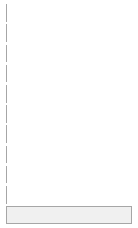

0  
(0.0%)

redcap_data_access_group  
[labelled, factor]

Data Access Group

1. acceso01  
2. acceso02  
3. acceso03  
4. acceso04  
5. acceso05  
6. acceso06  
7. acceso07  
8. acceso08  
9. acceso09  
10. acceso10  
[ 6 others ]

0 ( 0.0%)  
148 (10.6%)  
99 ( 7.1%)  
201 (14.4%)  
0 ( 0.0%)  
66 ( 4.7%)  
172 (12.3%)  
0 ( 0.0%)  
0 ( 0.0%)  
0 ( 0.0%)  
714 (51.0%)

3  
(0.2%)

recolect_id  
[labelled, character]

ID médico investigador

1. garomeroc  
2. ajsilva  
3. dbguerreroc  
4. egcasillah  
5. magarciaa  
6. nmhidalgos  
7. hlbojorquezc  
8. mlfernandezm  
9. corihuelaj  
10. psoteloj  
[ 3 others ]

260 (18.5%)  
200 (14.3%)  
197 (14.0%)  
193 (13.8%)  
187 (13.3%)  
177 (12.6%)  
54 ( 3.8%)  
34 ( 2.4%)  
30 ( 2.1%)  
28 ( 2.0%)  
43 ( 3.1%)

0  
(0.0%)

fecha_llenado  
[labelled, character]

Fecha y hora de llenado del formulario

1. 2022-01-29 10:19:00  
2. 2021-12-03 14:13:29  
3. 2021-12-04 11:37:20  
4. 2021-12-04 12:34:38  
5. 2021-12-05 10:52:07  
6. 2021-12-11 11:26:44  
7. 2021-12-13 11:48:34  
8. 2021-12-13 12:25:49  
9. 2021-12-14 09:24:36  
10. 2021-12-15 07:33:53  
[ 1392 others ]

2 ( 0.1%)  
1 ( 0.1%)  
1 ( 0.1%)  
1 ( 0.1%)  
1 ( 0.1%)  
1 ( 0.1%)  
1 ( 0.1%)  
1 ( 0.1%)  
1 ( 0.1%)  
1 ( 0.1%)  
1392 (99.2%)

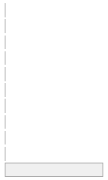

0  
(0.0%)

doc_tipo_otros  
[labelled, logical]

Otro tipo de documentos especificar

All NA’s

1403  
(100.0%)

sexo  
[labelled, factor]

Sexo

1. Femenino  
2. Masculino

424 (30.2%)  
979 (69.8%)

0  
(0.0%)

edad  
[labelled, integer]

Edad al ingreso a Emergencias

Mean (sd) : 57.2 (14.9)  
min < med < max:  
21 < 57 < 97  
IQR (CV) : 21.5 (0.3)

74 distinct values

0  
(0.0%)

sint_resp  
[labelled, factor]

Al momento del ingreso a Emergencias, ¿El paciente o acompañante de este reportó que el paciente era sintomático respiratorio?

1. Sí (historia lo indica)  
2. No (historia lo indica)  
3. Información no disponible

1306 (93.1%)  
70 ( 5.0%)  
27 ( 1.9%)

0  
(0.0%)

dx_covid_pcr  
[labelled, factor]

Prueba Molecular de RT-PCR

1. No cuenta con prueba o e  
2. Positivo (cuenta con prue  
3. Negativo (cuenta con prue

1181 (84.2%)  
202 (14.4%)  
20 ( 1.4%)

0  
(0.0%)

dx_covid_pantig  
[labelled, factor]

Prueba de Antígeno

1. No cuenta con prueba o e  
2. Positivo (cuenta con prue  
3. Negativo (cuenta con prue

820 (58.4%)  
442 (31.5%)  
141 (10.0%)

0  
(0.0%)

dx_covid_prapid  
[labelled, factor]

Prueba Rápida

1. No cuenta con prueba o e  
2. Positivo (cuenta con prue  
3. Negativo (cuenta con prue

1159 (82.6%)  
142 (10.1%)  
102 ( 7.3%)

0  
(0.0%)

dx_covid_clintac  
[labelled, factor]

Criterios clínicos tomográficos

1. No cuenta con prueba o e  
2. Positivo (cuenta con prue  
3. Negativo (cuenta con prue

191 (13.6%)  
1201 (85.6%)  
11 ( 0.8%)

0  
(0.0%)

emerg_admin  
[labelled, factor]

¿Fue admitido por el Servicio de Emergencias de CELIM COVID-19?

1. Sí  
2. No

1395 (99.4%)  
8 ( 0.6%)

0  
(0.0%)

emerg_admin_fecha  
[labelled, character]

Indicar fecha y hora de admisión al Servicio de Emergencias

1. 2021-06-02 18:57  
2. 2020-05-12 17:19  
3. 2020-05-19 14:34  
4. 2020-12-02 16:04  
5. 2020-12-10 20:54  
6. 2021-01-05 06:26  
7. 2021-01-14 18:47  
8. 2021-01-17 18:27  
9. 2021-01-19 20:37  
10. 2021-01-21 10:52  
[ 1354 others ]

3 ( 0.2%)  
2 ( 0.1%)  
2 ( 0.1%)  
2 ( 0.1%)  
2 ( 0.1%)  
2 ( 0.1%)  
2 ( 0.1%)  
2 ( 0.1%)  
2 ( 0.1%)  
2 ( 0.1%)  
1382 (98.5%)

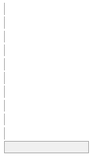

0  
(0.0%)

resid_ancian  
[labelled, factor]

¿El paciente vive en una residencia para ancianos, asilo, casa de reposo u otro similar?

1. Sí (historia lo indica)  
2. No (historia lo indica o  
3. Información no disponible

11 ( 0.8%)  
1312 (93.5%)  
80 ( 5.7%)

0  
(0.0%)

elegibilidad  
[labelled, integer]

Elegibilidad

Mean (sd) : 2.9 (0.3)  
min < med < max:  
1 < 3 < 3  
IQR (CV) : 0 (0.1)

1 : 7 ( 0.5%)  
2 : 68 ( 4.8%)  
3 : 1328 (94.7%)

0  
(0.0%)

sint_dia  
[labelled, character]

Tiempo desde inicio de síntomas (en días)

1. 7  
2. 10  
3. 14  
4. 8  
5. 5  
6. NI  
7. (Empty string)  
8. 9  
9. 3  
10. 4  
[ 22 others ]

268 (19.1%)  
172 (12.3%)  
118 ( 8.4%)  
96 ( 6.8%)  
88 ( 6.3%)  
77 ( 5.5%)  
75 ( 5.3%)  
69 ( 4.9%)  
65 ( 4.6%)  
58 ( 4.1%)  
317 (22.6%)

0  
(0.0%)

previo_covid  
[labelled, factor]

Indicar si historia refiere que paciente tuvo COVID-19 o infección por SARS-CoV-2 previamente al cuadro actual

1. Sí (historia lo indica)  
2. No (historia lo indica)  
3. Información no disponible

32 ( 2.4%)  
1032 (77.7%)  
264 (19.9%)

75  
(5.3%)

vacuna  
[labelled, factor]

Indicar si historia clínica refiere que paciente fue vacunado contra el COVID-19

1. Sí (historia lo indica)  
2. No (historia lo indica)  
3. Información no disponible

12 ( 0.9%)  
975 (73.4%)  
341 (25.7%)

75  
(5.3%)

sint_confusion  
[labelled, factor]

Confusión

1. Información no disponible  
2. Sí (historia lo indica)  
3. No (historia lo indica)

251 (18.9%)  
63 ( 4.7%)  
1014 (76.4%)

75  
(5.3%)

sint_disnea  
[labelled, factor]

Disnea

1. Información no disponible  
2. Sí (historia lo indica)  
3. No (historia lo indica)

45 ( 3.4%)  
1194 (89.9%)  
89 ( 6.7%)

75  
(5.3%)

sint_fiebre  
[labelled, factor]

Fiebre

1. Información no disponible  
2. Sí (historia lo indica)  
3. No (historia lo indica)

159 (12.0%)  
744 (56.0%)  
425 (32.0%)

75  
(5.3%)

sint_fatiga  
[labelled, factor]

Fatiga

1. Información no disponible  
2. Sí (historia lo indica)  
3. No (historia lo indica)

228 (17.2%)  
194 (14.6%)  
906 (68.2%)

75  
(5.3%)

sint_mialgia  
[labelled, factor]

Mialgia

1. Información no disponible  
2. Sí (historia lo indica)  
3. No (historia lo indica)

301 (22.7%)  
71 ( 5.3%)  
956 (72.0%)

75  
(5.3%)

sint_artralgia  
[labelled, factor]

Artralgia

1. Información no disponible  
2. Sí (historia lo indica)  
3. No (historia lo indica)

312 (23.5%)  
37 ( 2.8%)  
979 (73.7%)

75  
(5.3%)

sint_rash  
[labelled, factor]

Rash

1. Información no disponible  
2. Sí (historia lo indica)  
3. No (historia lo indica)

344 (25.9%)  
4 ( 0.3%)  
980 (73.8%)

75  
(5.3%)

sint_tosseca  
[labelled, factor]

Tos seca

1. Información no disponible  
2. Sí (historia lo indica)  
3. No (historia lo indica)

255 (19.2%)  
227 (17.1%)  
846 (63.7%)

75  
(5.3%)

sint_tosprod  
[labelled, factor]

Tos productiva

1. Información no disponible  
2. Sí (historia lo indica)  
3. No (historia lo indica)

281 (21.2%)  
96 ( 7.2%)  
951 (71.6%)

75  
(5.3%)

sint_tosnodef  
[labelled, factor]

Tos (no definido tipo)

1. Información no disponible  
2. Sí (historia lo indica)  
3. No (historia lo indica)

229 (17.2%)  
442 (33.3%)  
657 (49.5%)

75  
(5.3%)

sint_dolortox  
[labelled, factor]

Dolor de tórax

1. Información no disponible  
2. Sí (historia lo indica)  
3. No (historia lo indica)

314 (23.6%)  
116 ( 8.7%)  
898 (67.6%)

75  
(5.3%)

sint_hemopt  
[labelled, factor]

Hemoptisis

1. Información no disponible  
2. Sí (historia lo indica)  
3. No (historia lo indica)

341 (25.7%)  
8 ( 0.6%)  
979 (73.7%)

75  
(5.3%)

sint_sibil  
[labelled, factor]

Sibilancia

1. Información no disponible  
2. Sí (historia lo indica)  
3. No (historia lo indica)

341 (25.7%)  
5 ( 0.4%)  
982 (73.9%)

75  
(5.3%)

sint_dolorgarg  
[labelled, factor]

Dolor de garganta

1. Información no disponible  
2. Sí (historia lo indica)  
3. No (historia lo indica)

285 (21.5%)  
164 (12.3%)  
879 (66.2%)

75  
(5.3%)

sint_rinorr  
[labelled, factor]

Rinorrea

1. Información no disponible  
2. Sí (historia lo indica)  
3. No (historia lo indica)

328 (24.7%)  
49 ( 3.7%)  
951 (71.6%)

75  
(5.3%)

sint_hipogeu  
[labelled, factor]

Hipogeusia

1. Información no disponible  
2. Sí (historia lo indica)  
3. No (historia lo indica)

339 (25.5%)  
21 ( 1.6%)  
968 (72.9%)

75  
(5.3%)

sint_otalg  
[labelled, factor]

Otalgia

1. Información no disponible  
2. Sí (historia lo indica)  
3. No (historia lo indica)

345 (26.0%)  
2 ( 0.2%)  
981 (73.9%)

75  
(5.3%)

sint_diarr  
[labelled, factor]

Diarrea

1. Información no disponible  
2. Sí (historia lo indica)  
3. No (historia lo indica)

316 (23.8%)  
102 ( 7.7%)  
910 (68.5%)

75  
(5.3%)

sint_nausea  
[labelled, factor]

Náuseas

1. Información no disponible  
2. Sí (historia lo indica)  
3. No (historia lo indica)

335 (25.2%)  
39 ( 2.9%)  
954 (71.8%)

75  
(5.3%)

sint_vomit  
[labelled, factor]

Vómitos

1. Información no disponible  
2. Sí (historia lo indica)  
3. No (historia lo indica)

340 (25.6%)  
25 ( 1.9%)  
963 (72.5%)

75  
(5.3%)

sint_dolorabdom  
[labelled, factor]

Dolor abdominal

1. Información no disponible  
2. Sí (historia lo indica)  
3. No (historia lo indica)

336 (25.3%)  
24 ( 1.8%)  
968 (72.9%)

75  
(5.3%)

sint_cefalea  
[labelled, factor]

Cefalea

1. Información no disponible  
2. Sí (historia lo indica)  
3. No (historia lo indica)

300 (22.6%)  
159 (12.0%)  
869 (65.4%)

75  
(5.3%)

oxigen  
[labelled, factor]

Dispositivo para la adminsitración de oxígeno al momento del ingreso

1. Sí (historia lo indica)  
2. No (historia lo indica)  
3. Información no disponible

680 (51.2%)  
585 (44.1%)  
63 ( 4.7%)

75  
(5.3%)

oxigen_tipo  
[labelled, factor]

Tipo de apoyo oxigenatorio al ingreso

1. Cánula simple  
2. Mascarilla simple  
3. Mascarilla venturi  
4. Mascarilla de reservorio  
5. Cánula nasal simple + mas  
6. Cánula de Alto Flujo  
7. Ventilador mecánico  
8. Otras {oxigen_tipo_espec:

60 ( 8.8%)  
2 ( 0.3%)  
6 ( 0.9%)  
561 (82.6%)  
1 ( 0.1%)  
2 ( 0.3%)  
46 ( 6.8%)  
1 ( 0.1%)

724  
(51.6%)

oxigen_tipo_espec  
[labelled, character]

Especificar tipo de dispositivo de oxigeno - otros

1. (Empty string)  
2. CANULA BINASAL·  
3. NI

1400 (99.8%)  
1 ( 0.1%)  
2 ( 0.1%)

0  
(0.0%)

oxigen_aporte  
[labelled, character]

Aporte de oxígeno en litros

1. (Empty string)  
2. 15  
3. NI  
4. 5  
5. 10  
6. 8  
7. 13  
8. 12  
9. 7  
10. 4  
[ 10 others ]

723 (51.5%)  
501 (35.7%)  
63 ( 4.5%)  
43 ( 3.1%)  
32 ( 2.3%)  
7 ( 0.5%)  
6 ( 0.4%)  
5 ( 0.4%)  
5 ( 0.4%)  
4 ( 0.3%)  
14 ( 1.0%)

0  
(0.0%)

alter_mental  
[labelled, factor]

¿Presentó ESTADO MENTAL, DE CONCIENCIA O SENSORIO ALTERADO en la evaluación de INGRESO A EMERGENCIA?

1. Sí (historia lo indica)  
2. No (historia lo indica)  
3. Información no disponible

165 (12.4%)  
1137 (85.6%)  
26 ( 2.0%)

75  
(5.3%)

sv_temp_sino  
[labelled, factor]

Temperatura - tiene

1. Si  
2. No

346 (26.1%)  
982 (73.9%)

75  
(5.3%)

sv_fr_sino  
[labelled, factor]

Frecuencia respiratoria - tiene

1. Si  
2. No

1204 (90.7%)  
124 ( 9.3%)

75  
(5.3%)

sv_fc_sino  
[labelled, factor]

Pulso/Frecuencia Cardíaca - tiene

1. Si  
2. No

1257 (94.7%)  
71 ( 5.3%)

75  
(5.3%)

sv_pas_sino  
[labelled, factor]

Presión Arterial Sistólica - tiene

1. Si  
2. No

1146 (86.3%)  
182 (13.7%)

75  
(5.3%)

sv_pad_sino  
[labelled, factor]

Presión Arterial Diastólica - tiene

1. Si  
2. No

1142 (86.0%)  
186 (14.0%)

75  
(5.3%)

sv_satoamb_sino  
[labelled, factor]

Saturación de Oxígeno con aire ambiental - tiene

1. Si  
2. No

557 (42.0%)  
770 (58.0%)

76  
(5.4%)

sv_satodisp_sino  
[labelled, factor]

Saturación de Oxígeno con dispositivo - tiene

1. Si  
2. No

683 (51.4%)  
645 (48.6%)

75  
(5.3%)

sv_glasgow_sino  
[labelled, factor]

Puntaje Glasgow - tiene

1. Si  
2. No

708 (53.6%)  
613 (46.4%)

82  
(5.8%)

sv_temp_res  
[labelled, numeric]

Temperatura (Celsius) - Resultado

Mean (sd) : 36.8 (0.6)  
min < med < max:  
35 < 36.8 < 39.5  
IQR (CV) : 0.5 (0)

31 distinct values

1057  
(75.3%)

sv_fr_res  
[labelled, integer]

Frecuencia respiratoria - Resultado

Mean (sd) : 27.2 (5.5)  
min < med < max:  
10 < 26 < 77  
IQR (CV) : 6 (0.2)

37 distinct values

199  
(14.2%)

sv_fc_res  
[labelled, integer]

Pulso/Frecuencia Cardíaca - Resultado

Mean (sd) : 95.5 (17.3)  
min < med < max:  
37 < 94 < 180  
IQR (CV) : 24 (0.2)

99 distinct values

146  
(10.4%)

sv_pas_res  
[labelled, integer]

Presión Arterial Sistólica - Resultado

Mean (sd) : 117.2 (17.3)  
min < med < max:  
40 < 120 < 205  
IQR (CV) : 18 (0.1)

78 distinct values

257  
(18.3%)

sv_pad_res  
[labelled, integer]

Presión Arterial Diastólica - Resultado

Mean (sd) : 70.2 (10.3)  
min < med < max:  
20 < 70 < 110  
IQR (CV) : 20 (0.1)

52 distinct values

261  
(18.6%)

sv_satoamb_res  
[labelled, character]

Saturación de Oxígeno aire ambiental - Resultado

1. (Empty string)  
2. 90  
3. 92  
4. 85  
5. 88  
6. 80  
7. 93  
8. 89  
9. 87  
10. 84  
[ 62 others ]

846 (60.3%)  
43 ( 3.1%)  
30 ( 2.1%)  
28 ( 2.0%)  
28 ( 2.0%)  
27 ( 1.9%)  
27 ( 1.9%)  
25 ( 1.8%)  
23 ( 1.6%)  
21 ( 1.5%)  
305 (21.7%)

0  
(0.0%)

sv_satodisp_res  
[labelled, character]

Saturación de Oxígeno con dispositivo - Resultado

1. (Empty string)  
2. 94  
3. 88  
4. 90  
5. 95  
6. 96  
7. 98  
8. 89  
9. 93  
10. 92  
[ 61 others ]

718 (51.2%)  
51 ( 3.6%)  
47 ( 3.3%)  
46 ( 3.3%)  
45 ( 3.2%)  
36 ( 2.6%)  
33 ( 2.4%)  
28 ( 2.0%)  
28 ( 2.0%)  
27 ( 1.9%)  
344 (24.5%)

0  
(0.0%)

sv_satodisp_fio2  
[labelled, character]

FiO2 (%)

1. (Empty string)  
2. 0.8  
3. 1.0  
4. 0.4  
5. 0.9  
6. 0.6  
7. 0.3  
8. 0.2  
9. 0.7  
10. NI  
[ 4 others ]

720 (51.3%)  
474 (33.8%)  
67 ( 4.8%)  
53 ( 3.8%)  
38 ( 2.7%)  
13 ( 0.9%)  
9 ( 0.6%)  
8 ( 0.6%)  
7 ( 0.5%)  
7 ( 0.5%)  
7 ( 0.5%)

0  
(0.0%)

sv_glasgow_res  
[labelled, integer]

Puntaje Glasgow - Resultado

Mean (sd) : 14.6 (1.4)  
min < med < max:  
3 < 15 < 15  
IQR (CV) : 0 (0.1)

13 distinct values

695  
(49.5%)

hepatomeg  
[labelled, factor]

¿Tiene hepatomegalia? La evaluación puede ser semiológica o por imágenes.

1. Sí (historia lo indica)  
2. No (historia lo indica)  
3. Información no disponible

6 ( 0.5%)  
1142 (86.0%)  
180 (13.6%)

75  
(5.3%)

esplenomeg  
[labelled, factor]

¿Tiene esplenomegalia? La evaluación puede ser semiológica o por imágenes.

1. Sí (historia lo indica)  
2. No (historia lo indica)  
3. Información no disponible

4 ( 0.3%)  
1144 (86.1%)  
180 (13.6%)

75  
(5.3%)

com_neop  
[labelled, factor]

Enfermedad neoplásica

1. Sí (historia lo indica)  
2. No (historia lo indica)  
3. Información no disponible

36 ( 2.7%)  
1098 (82.7%)  
194 (14.6%)

75  
(5.3%)

com_hepa_leve  
[labelled, factor]

Hepatopatía leve

1. Sí (historia lo indica)  
2. No (historia lo indica)  
3. Información no disponible

2 ( 0.2%)  
1128 (84.9%)  
198 (14.9%)

75  
(5.3%)

com_hepa_modsev  
[labelled, factor]

Hepatopatía moderada a severa

1. Sí (historia lo indica)  
2. No (historia lo indica)  
3. Información no disponible

5 ( 0.4%)  
1123 (84.6%)  
200 (15.1%)

75  
(5.3%)

com_fcc  
[labelled, factor]

Falla cardíaca congestiva

1. Sí (historia lo indica)  
2. No (historia lo indica)  
3. Información no disponible

3 ( 0.2%)  
1121 (84.4%)  
204 (15.4%)

75  
(5.3%)

com_ecv  
[labelled, factor]

Enfermedad cerebrovascular

1. Sí (historia lo indica)  
2. No (historia lo indica)  
3. Información no disponible

5 ( 0.4%)  
1122 (84.5%)  
201 (15.1%)

75  
(5.3%)

com_er  
[labelled, factor]

Historia de enfermedad renal

1. Sí (historia lo indica)  
2. No (historia lo indica)  
3. Información no disponible

26 ( 2.0%)  
1102 (83.0%)  
200 (15.1%)

75  
(5.3%)

com_im  
[labelled, factor]

Infarto a miocardio

1. Sí (historia lo indica)  
2. No (historia lo indica)  
3. Información no disponible

12 ( 0.9%)  
1115 (84.0%)  
201 (15.1%)

75  
(5.3%)

com_evp  
[labelled, factor]

Enfermedad vascular periférica

1. Sí (historia lo indica)  
2. No (historia lo indica)  
3. Información no disponible

4 ( 0.3%)  
1122 (84.5%)  
202 (15.2%)

75  
(5.3%)

com_tia  
[labelled, factor]

Accidente isquémico transitorio

1. Sí (historia lo indica)  
2. No (historia lo indica)  
3. Información no disponible

3 ( 0.2%)  
1123 (84.6%)  
202 (15.2%)

75  
(5.3%)

com_demen  
[labelled, factor]

Demencia

1. Sí (historia lo indica)  
2. No (historia lo indica)  
3. Información no disponible

11 ( 0.8%)  
1123 (84.6%)  
194 (14.6%)

75  
(5.3%)

com_epoc  
[labelled, factor]

Enfermedad Pulmonar Obstructiva Crónica

1. Sí (historia lo indica)  
2. No (historia lo indica)  
3. Información no disponible

9 ( 0.7%)  
1118 (84.2%)  
201 (15.1%)

75  
(5.3%)

com_etc  
[labelled, factor]

Enfermedad del tejido conjuntivo

1. Sí (historia lo indica)  
2. No (historia lo indica)  
3. Información no disponible

7 ( 0.5%)  
1120 (84.3%)  
201 (15.1%)

75  
(5.3%)

com_dmnc  
[labelled, factor]

Diabetes mellitus NO complicada

1. Sí (historia lo indica)  
2. No (historia lo indica)  
3. Información no disponible

212 (16.0%)  
965 (72.7%)  
151 (11.4%)

75  
(5.3%)

com_dmc  
[labelled, factor]

Diabetes mellitus COMPLICADA (con daño de órgano blanco)

1. Sí (historia lo indica)  
2. No (historia lo indica)  
3. Información no disponible

19 ( 1.4%)  
1124 (84.6%)  
185 (13.9%)

75  
(5.3%)

com_hemip  
[labelled, factor]

Hemiplejía

1. Sí (historia lo indica)  
2. No (historia lo indica)  
3. Información no disponible

2 ( 0.2%)  
1128 (84.9%)  
198 (14.9%)

75  
(5.3%)

com_erc_modsev  
[labelled, factor]

Enfermedad renal crónica moderada a severa

1. Sí (historia lo indica)  
2. No (historia lo indica)  
3. Información no disponible

28 ( 2.1%)  
1100 (82.8%)  
200 (15.1%)

75  
(5.3%)

com_tsol_loc  
[labelled, factor]

Tumor sólido localizado

1. Sí (historia lo indica)  
2. No (historia lo indica)  
3. Información no disponible

5 ( 0.4%)  
1125 (84.7%)  
198 (14.9%)

75  
(5.3%)

com_tsol_met  
[labelled, factor]

Tumor sólido metastásico

1. Sí (historia lo indica)  
2. No (historia lo indica)  
3. Información no disponible

3 ( 0.2%)  
1127 (84.9%)  
198 (14.9%)

75  
(5.3%)

com_leuc  
[labelled, factor]

Leucemia

1. Sí (historia lo indica)  
2. No (historia lo indica)  
3. Información no disponible

1 ( 0.1%)  
1126 (84.8%)  
201 (15.1%)

75  
(5.3%)

com_linf  
[labelled, factor]

Linfoma

1. Sí (historia lo indica)  
2. No (historia lo indica)  
3. Información no disponible

0 ( 0.0%)  
1128 (84.9%)  
200 (15.1%)

75  
(5.3%)

com_sida  
[labelled, factor]

SIDA

1. Sí (historia lo indica)  
2. No (historia lo indica)  
3. Información no disponible

0 ( 0.0%)  
1128 (84.9%)  
200 (15.1%)

75  
(5.3%)

com_hta  
[labelled, factor]

Hipertensión Arterial

1. Sí (historia lo indica)  
2. No (historia lo indica)  
3. Información no disponible

370 (26.4%)  
874 (62.3%)  
158 (11.3%)

1  
(0.1%)

antec_vacuna  
[labelled, factor]

¿El paciente ya ha sido vacunado?

1. Sí  
2. No  
3. Información no disponible

10 ( 0.9%)  
743 (67.7%)  
344 (31.4%)

306  
(21.8%)

antec_vacuna_dosis  
[labelled, factor]

¿Cuántas dosis?

1. Una dosis  
2. Dos dosis  
3. Tres dosis  
4. Información no disponible

5 (50.0%)  
2 (20.0%)  
0 ( 0.0%)  
3 (30.0%)

1393  
(99.3%)

inm_vih  
[labelled, factor]

VIH positivo

1. Sí (historia lo indica)  
2. No (historia lo indica)  
3. Información no disponible

4 ( 0.3%)  
948 (71.4%)  
376 (28.3%)

75  
(5.3%)

inm_ttoinmsup  
[labelled, factor]

Terapia de imunosupresión de larga data (p. ej., glucocorticoides, ciclosporina, azatiopina, etc.)

1. Sí (historia lo indica)  
2. No (historia lo indica)  
3. Información no disponible

20 ( 1.5%)  
932 (70.2%)  
376 (28.3%)

75  
(5.3%)

inm_inmsup_prim  
[labelled, factor]

Inmunodeficiencia primaria

1. Sí (historia lo indica)  
2. No (historia lo indica)  
3. Información no disponible

0 ( 0.0%)  
949 (71.5%)  
379 (28.5%)

75  
(5.3%)

peso_sino  
[labelled, factor]

Peso - tiene

1. Sí (historia lo indica)  
2. No (historia lo indica)  
3. Información no disponible

55 ( 4.1%)  
476 (35.8%)  
797 (60.0%)

75  
(5.3%)

talla_sino  
[labelled, factor]

Talla - tiene

1. Sí (historia lo indica)  
2. No (historia lo indica)  
3. Información no disponible

44 ( 3.3%)  
482 (36.3%)  
802 (60.4%)

75  
(5.3%)

obesidad_sino  
[labelled, factor]

Obesidad - tiene

1. Sí (historia lo indica)  
2. No (historia lo indica)  
3. Información no disponible

297 (22.4%)  
344 (25.9%)  
687 (51.7%)

75  
(5.3%)

peso_res  
[labelled, numeric]

Peso - resultado

Mean (sd) : 92.1 (20.4)  
min < med < max:  
55 < 90 < 150  
IQR (CV) : 20 (0.2)

31 distinct values

1348  
(96.1%)

talla_res  
[labelled, numeric]

Talla - resultado

Mean (sd) : 1.7 (0.1)  
min < med < max:  
1.5 < 1.7 < 1.8  
IQR (CV) : 0.1 (0)

20 distinct values

1359  
(96.9%)

obesidad_res  
[labelled, factor]

Obesidad - resultado

1. Sí (IMC > 30)  
2. No (IMC < = 30)  
3. Sí (sin medición de IMC,  
4. No (sin medición de IMC,

44 (14.8%)  
11 ( 3.7%)  
142 (47.8%)  
100 (33.7%)

1106  
(78.8%)

fecha_labo  
[labelled, character]

Fecha de resultados de laboratorio

1. NI  
2. 2021-01-31  
3. 2021-02-21  
4. 2021-02-22  
5. 2021-02-16  
6. 2020-05-12  
7. 2020-05-30  
8. 2020-12-29  
9. 2021-01-21  
10. 2021-06-11  
[ 248 others ]

105 ( 7.5%)  
19 ( 1.4%)  
17 ( 1.2%)  
17 ( 1.2%)  
16 ( 1.1%)  
14 ( 1.0%)  
14 ( 1.0%)  
14 ( 1.0%)  
14 ( 1.0%)  
14 ( 1.0%)  
1159 (82.6%)

0  
(0.0%)

lab_sino_sod  
[labelled, factor]

Sodio - tiene resultados

1. Sí  
2. No

972 (73.2%)  
356 (26.8%)

75  
(5.3%)

lab_sino_clor  
[labelled, factor]

Cloro - tiene resultados

1. Sí  
2. No

892 (67.2%)  
436 (32.8%)

75  
(5.3%)

lab_sino_potas  
[labelled, factor]

Potasio - tiene resultados

1. Sí  
2. No

970 (73.0%)  
358 (27.0%)

75  
(5.3%)

lab_sino_urea  
[labelled, factor]

Urea - tiene resultados

1. Sí  
2. No

1014 (76.4%)  
314 (23.6%)

75  
(5.3%)

lab_sino_creat  
[labelled, factor]

Creatinina - tiene resultados

1. Sí  
2. No

1059 (79.7%)  
269 (20.3%)

75  
(5.3%)

lab_sino_gluc  
[labelled, factor]

Glucosa - tiene resultados

1. Sí  
2. No

1018 (76.7%)  
310 (23.3%)

75  
(5.3%)

lab_sino_album  
[labelled, factor]

Albúmina - tiene resultados

1. Sí  
2. No

839 (63.2%)  
489 (36.8%)

75  
(5.3%)

lab_sino_hcto  
[labelled, factor]

Hematocrito - tiene resultados

1. Sí  
2. No

926 (69.7%)  
402 (30.3%)

75  
(5.3%)

lab_sino_hb  
[labelled, factor]

Hemoglobina - tiene resultados

1. Sí  
2. No

1060 (79.8%)  
268 (20.2%)

75  
(5.3%)

lab_sino_leuc  
[labelled, factor]

Conteo de leucocitos - tiene resultados

1. Sí  
2. No

1115 (84.0%)  
213 (16.0%)

75  
(5.3%)

lab_sino_neut  
[labelled, factor]

Conteo de neutrófilos - tiene resultados

1. Sí  
2. No

943 (71.0%)  
385 (29.0%)

75  
(5.3%)

lab_sino_granul  
[labelled, factor]

Recuento de granulocitos inmaduros - tiene resultados

1. Sí  
2. No

906 (68.2%)  
422 (31.8%)

75  
(5.3%)

lab_sino_linf  
[labelled, factor]

Conteo de linfocitos - tiene resultados

1. Sí  
2. No

1013 (76.3%)  
315 (23.7%)

75  
(5.3%)

lab_sino_plaq  
[labelled, factor]

Conteo de plaquetas - tiene resultados

1. Sí  
2. No

1023 (77.0%)  
305 (23.0%)

75  
(5.3%)

lab_sino_ph  
[labelled, factor]

pH - tiene resultados

1. Sí  
2. No

1092 (82.2%)  
236 (17.8%)

75  
(5.3%)

lab_sino_pao2  
[labelled, factor]

Presión parcial de oxígeno - tiene resultados

1. Sí  
2. No

1095 (82.5%)  
233 (17.5%)

75  
(5.3%)

lab_sino_pco2  
[labelled, factor]

Presión parcial de CO2 - tiene resultados

1. Sí  
2. No

1108 (83.4%)  
220 (16.6%)

75  
(5.3%)

lab_sino_fio2  
[labelled, factor]

Fracción de oxígeno inspirado - tiene resultados

1. Sí  
2. No

1002 (75.5%)  
326 (24.5%)

75  
(5.3%)

lab_sino_gaa  
[labelled, factor]

Gradiente Alveolo-Arterial - tiene resultados

1. Sí  
2. No

841 (63.3%)  
487 (36.7%)

75  
(5.3%)

lab_sino_pafi  
[labelled, factor]

PAFI - tiene resultados

1. Sí  
2. No

1144 (86.1%)  
184 (13.9%)

75  
(5.3%)

lab_sino_lact  
[labelled, factor]

Lactato - tiene resultados

1. Sí  
2. No

1055 (79.4%)  
273 (20.6%)

75  
(5.3%)

lab_sino_dimd  
[labelled, factor]

Dímero D - tiene resultados

1. Sí  
2. No

880 (66.3%)  
448 (33.7%)

75  
(5.3%)

lab_sino_fibri  
[labelled, factor]

Fibrinógeno - tiene resultados

1. Sí  
2. No

903 (68.0%)  
425 (32.0%)

75  
(5.3%)

lab_sino_dhl  
[labelled, factor]

Deshidrogenasa láctica - tiene resultados

1. Sí  
2. No

934 (70.3%)  
394 (29.7%)

75  
(5.3%)

lab_sino_pcr  
[labelled, factor]

Proteína C reactiva - tiene resultados

1. Sí  
2. No

980 (73.8%)  
348 (26.2%)

75  
(5.3%)

lab_sino_ferrit  
[labelled, factor]

Ferritina - tiene resultados

1. Sí  
2. No

649 (48.9%)  
679 (51.1%)

75  
(5.3%)

lab_sino_falc  
[labelled, factor]

Fosfatasa alcalina - tiene resultados

1. Sí  
2. No

825 (62.1%)  
503 (37.9%)

75  
(5.3%)

lab_sino_tgo  
[labelled, factor]

TGO - tiene resultados

1. Sí  
2. No

876 (66.0%)  
452 (34.0%)

75  
(5.3%)

lab_sino_tgp  
[labelled, factor]

TGP - tiene resultados

1. Sí  
2. No

868 (65.4%)  
460 (34.6%)

75  
(5.3%)

lab_sino_trigli  
[labelled, factor]

Triglicéridos - tiene resultados

1. Sí  
2. No

1 ( 0.1%)  
1327 (99.9%)

75  
(5.3%)

lab_res_sod  
[labelled, numeric]

Sodio - resultado

Mean (sd) : 138.8 (6.2)  
min < med < max:  
40 < 139 < 177.3  
IQR (CV) : 5.3 (0)

210 distinct values

431  
(30.7%)

lab_res_clor  
[labelled, numeric]

Cloro - resultado

Mean (sd) : 103.5 (5.6)  
min < med < max:  
75 < 103.5 < 141.6  
IQR (CV) : 5.8 (0.1)

227 distinct values

511  
(36.4%)

lab_res_potas  
[labelled, numeric]

Potasio - resultado

Mean (sd) : 4.3 (1.5)  
min < med < max:  
1.6 < 4.2 < 40.2  
IQR (CV) : 0.7 (0.3)

252 distinct values

433  
(30.9%)

lab_res_urea  
[labelled, numeric]

Urea - resultado

Mean (sd) : 50.1 (44.6)  
min < med < max:  
0.2 < 37.5 < 656.8  
IQR (CV) : 25 (0.9)

540 distinct values

389  
(27.7%)

lab_res_creat  
[labelled, numeric]

Creatinina - resultado

Mean (sd) : 1.2 (2.2)  
min < med < max:  
0.3 < 0.8 < 50.2  
IQR (CV) : 0.3 (1.9)

201 distinct values

344  
(24.5%)

lab_res_gluc  
[labelled, numeric]

Glucosa - resultado

Mean (sd) : 155.4 (82.6)  
min < med < max:  
0.9 < 131 < 955  
IQR (CV) : 60 (0.5)

236 distinct values

385  
(27.4%)

lab_res_album  
[labelled, numeric]

Albúmina - resultado

Mean (sd) : 3.6 (0.5)  
min < med < max:  
1.3 < 3.7 < 6.4  
IQR (CV) : 0.6 (0.1)

210 distinct values

564  
(40.2%)

lab_res_hcto  
[labelled, numeric]

Hematocrito - resultado

Mean (sd) : 39.2 (5.8)  
min < med < max:  
8.6 < 39.7 < 57.9  
IQR (CV) : 7 (0.1)

235 distinct values

477  
(34.0%)

lab_res_hb  
[labelled, numeric]

Hemoglobina - resultado

Mean (sd) : 13.5 (2.3)  
min < med < max:  
3 < 13.6 < 42.2  
IQR (CV) : 2.5 (0.2)

123 distinct values

343  
(24.4%)

lab_res_leuc  
[labelled, numeric]

Conteo de leucocitos - resultado

Mean (sd) : 44.5 (626.8)  
min < med < max:  
0.5 < 11.7 < 16380  
IQR (CV) : 7.9 (14.1)

802 distinct values

288  
(20.5%)

lab_res_neut  
[labelled, numeric]

Conteo de neutrófilos - resultado

Mean (sd) : 26.7 (468)  
min < med < max:  
0.2 < 9.9 < 14380  
IQR (CV) : 7.3 (17.6)

717 distinct values

460  
(32.8%)

lab_res_granul  
[labelled, numeric]

Recuento de granulocitos inmaduros - resultado

Mean (sd) : 0.3 (0.4)  
min < med < max:  
0 < 0.1 < 3.9  
IQR (CV) : 0.3 (1.5)

129 distinct values

497  
(35.4%)

lab_res_linf  
[labelled, numeric]

Conteo de linfocitos - resultado

Mean (sd) : 2.6 (48.1)  
min < med < max:  
0 < 0.8 < 1530  
IQR (CV) : 0.7 (18.6)

224 distinct values

390  
(27.8%)

lab_res_plaq  
[labelled, numeric]

Conteo de plaquetas - resultado

Mean (sd) : 294.3 (118.8)  
min < med < max:  
1 < 279 < 995  
IQR (CV) : 147 (0.4)

392 distinct values

380  
(27.1%)

lab_res_ph  
[labelled, numeric]

pH - resultado

Mean (sd) : 7.4 (0.2)  
min < med < max:  
3.7 < 7.4 < 7.6  
IQR (CV) : 0.1 (0)

165 distinct values

311  
(22.2%)

lab_res_pao2  
[labelled, numeric]

Presión parcial de oxígeno - resultado

Mean (sd) : 71.8 (34.7)  
min < med < max:  
7.5 < 63.9 < 335  
IQR (CV) : 31 (0.5)

559 distinct values

308  
(22.0%)

lab_res_pco2  
[labelled, numeric]

Presión parcial de CO2 - resultado

Mean (sd) : 39.2 (19.4)  
min < med < max:  
9.1 < 33.9 < 239  
IQR (CV) : 9.4 (0.5)

386 distinct values

295  
(21.0%)

lab_res_fio2  
[labelled, character]

Fracción de oxígeno inspirado - resultado

1. 0.8  
2. (Empty string)  
3. 0.21  
4. 1  
5. 0.4  
6. 0.9  
7. 0.2  
8. 0.6  
9. 0.80  
10. 0.7  
[ 21 others ]

551 (39.3%)  
401 (28.6%)  
197 (14.0%)  
102 ( 7.3%)  
38 ( 2.7%)  
22 ( 1.6%)  
18 ( 1.3%)  
14 ( 1.0%)  
14 ( 1.0%)  
7 ( 0.5%)  
39 ( 2.8%)

0  
(0.0%)

lab_res_gaa  
[labelled, numeric]

Gradiente Alveolo-Arterial - resultado

Mean (sd) : 340.7 (195.5)  
min < med < max:  
2.6 < 440 < 639.1  
IQR (CV) : 345 (0.6)

694 distinct values

562  
(40.1%)

lab_res_pafi  
[labelled, numeric]

PAFI - resultado

Mean (sd) : 140.2 (95.8)  
min < med < max:  
0.6 < 100 < 600  
IQR (CV) : 122 (0.7)

658 distinct values

259  
(18.5%)

lab_res_lact  
[labelled, numeric]

Lactato - resultado

Mean (sd) : 1.9 (1.9)  
min < med < max:  
0 < 1.4 < 19  
IQR (CV) : 0.9 (1)

117 distinct values

348  
(24.8%)

lab_res_dimd  
[labelled, numeric]

Dímero D - resultado

Mean (sd) : 3.6 (6.8)  
min < med < max:  
0 < 1.1 < 36.6  
IQR (CV) : 2 (1.9)

349 distinct values

523  
(37.3%)

lab_res_fibri  
[labelled, numeric]

Fibrinógeno - resultado

Mean (sd) : 651.6 (227)  
min < med < max:  
30.8 < 600.6 < 1600  
IQR (CV) : 296.1 (0.3)

783 distinct values

500  
(35.6%)

lab_res_dhl  
[labelled, numeric]

Deshidrogenasa láctica - resultado

Mean (sd) : 539 (510.1)  
min < med < max:  
0.6 < 474 < 12897  
IQR (CV) : 279.5 (0.9)

521 distinct values

469  
(33.4%)

lab_res_pcr  
[labelled, numeric]

Proteína C Reactiva - resultado

Mean (sd) : 18.2 (12.2)  
min < med < max:  
0.3 < 16.5 < 180.3  
IQR (CV) : 17.2 (0.7)

778 distinct values

423  
(30.1%)

lab_res_ferrit  
[labelled, character]

Ferritina - resultado

1. (Empty string)  
2. 1501  
3. 1500  
4. 1500.0  
5. 981  
6. 1031  
7. 1087  
8. 1112.61  
9. 1175.39  
10. 124.5  
[ 541 others ]

754 (53.7%)  
28 ( 2.0%)  
26 ( 1.9%)  
11 ( 0.8%)  
3 ( 0.2%)  
2 ( 0.1%)  
2 ( 0.1%)  
2 ( 0.1%)  
2 ( 0.1%)  
2 ( 0.1%)  
571 (40.7%)

0  
(0.0%)

lab_res_falc  
[labelled, numeric]

Fosfatasa alcalina - resultado

Mean (sd) : 133.1 (98.4)  
min < med < max:  
2.1 < 106 < 1627  
IQR (CV) : 71 (0.7)

239 distinct values

578  
(41.2%)

lab_res_tgo  
[labelled, numeric]

TGO - resultado

Mean (sd) : 83.5 (139.9)  
min < med < max:  
3.5 < 59 < 2980  
IQR (CV) : 50 (1.7)

192 distinct values

527  
(37.6%)

lab_res_tgp  
[labelled, numeric]

TGP - resultado

Mean (sd) : 87.1 (131)  
min < med < max:  
3.7 < 63 < 2742  
IQR (CV) : 63.2 (1.5)

215 distinct values

535  
(38.1%)

lab_res_trigli  
[labelled, integer]

Triglicéridos - resultado

1 distinct value

150 : 1 (100.0%)

1402  
(99.9%)

rx_fecha  
[labelled, character]

Fecha de toma de radiografía de tórax

1. (Empty string)  
2. 2021-06-11  
3. 2021-02-19  
4. 2021-02-23  
5. 2021-06-08  
6. 2021-06-12  
7. 2021-06-18  
8. 2021-06-25  
9. 2021-01-21  
10. 2021-02-12  
[ 89 others ]

1213 (86.5%)  
7 ( 0.5%)  
6 ( 0.4%)  
5 ( 0.4%)  
5 ( 0.4%)  
5 ( 0.4%)  
5 ( 0.4%)  
5 ( 0.4%)  
4 ( 0.3%)  
4 ( 0.3%)  
144 (10.3%)

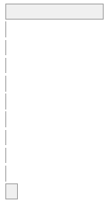

0  
(0.0%)

rx_tiene  
[labelled, factor]

¿Cuenta con radiografía de tórax tomada al ingreso en Emergencia?

1. Si  
2. No

190 (14.3%)  
1138 (85.7%)

75  
(5.3%)

rx_efuspleu  
[labelled, factor]

Efusión pleural según radiografía de tórax

1. Si  
2. No

4 ( 2.1%)  
186 (97.9%)

1213  
(86.5%)

rx_infilt  
[labelled, factor]

Infiltrado pulmonar según radiografía de tórax

1. Si  
2. No

186 (97.9%)  
4 ( 2.1%)

1213  
(86.5%)

rx_compro_na___1  
[labelled, factor]

No evaluación de compromiso pulmonar por radiografía de tórax (choice=No cuenta con evaluación de compromiso)

1. Unchecked  
2. Checked

1243 (88.6%)  
160 (11.4%)

0  
(0.0%)

rx_compro_na___ni  
[labelled, factor]

No evaluación de compromiso pulmonar por radiografía de tórax (choice=No information)

1. Unchecked  
2. Checked

1403 (100.0%)  
0 ( 0.0%)

0  
(0.0%)

rx_compro  
[labelled, integer]

Compromiso pulmonar por radiografía de tórax

Mean (sd) : 74 (19.4)  
min < med < max:  
20 < 80 < 100  
IQR (CV) : 23.8 (0.3)

20 : 1 ( 3.3%)  
25 : 1 ( 3.3%)  
50 : 2 ( 6.7%)  
60 : 3 (10.0%)  
65 : 1 ( 3.3%)  
70 : 5 (16.7%)  
80 : 7 (23.3%)  
90 : 8 (26.7%)  
100 : 2 ( 6.7%)

1373  
(97.9%)

tag_tiene  
[labelled, factor]

¿Cuenta con tomografía de tórax tomada al ingreso en Emergencia?

1. Si  
2. No

1223 (92.1%)  
105 ( 7.9%)

75  
(5.3%)

tag_fecha  
[labelled, character]

Fecha de toma de tomgorafía de tórax

1. (Empty string)  
2. 2020-05-05  
3. 2021-01-21  
4. 2020-05-21  
5. 2020-05-26  
6. 2021-01-18  
7. 2021-01-30  
8. 2021-01-31  
9. 2021-02-02  
10. 2021-02-16  
[ 241 others ]

180 (12.8%)  
16 ( 1.1%)  
15 ( 1.1%)  
13 ( 0.9%)  
13 ( 0.9%)  
13 ( 0.9%)  
13 ( 0.9%)  
13 ( 0.9%)  
13 ( 0.9%)  
13 ( 0.9%)  
1101 (78.5%)

0  
(0.0%)

tag_efuspleu  
[labelled, factor]

Efusión pleural según tomografía de tórax

1. Si  
2. No

39 ( 3.2%)  
1183 (96.8%)

181  
(12.9%)

tag_infilt  
[labelled, factor]

Infiltrado pulmonar según tomografía de tórax

1. Si  
2. No

1203 (98.4%)  
19 ( 1.6%)

181  
(12.9%)

tag_compro_na___1  
[labelled, factor]

No evaluación de compromiso pulmonar por tomografía de tórax (choice=No cuenta con evaluación de compromiso)

1. Unchecked  
2. Checked

1161 (82.8%)  
242 (17.2%)

0  
(0.0%)

tag_compro_na___ni  
[labelled, factor]

No evaluación de compromiso pulmonar por tomografía de tórax (choice=No information)

1. Unchecked  
2. Checked

1403 (100.0%)  
0 ( 0.0%)

0  
(0.0%)

tag_compro  
[labelled, integer]

Compromiso pulmonar por tomografía de tórax

Mean (sd) : 69.4 (19.3)  
min < med < max:  
5 < 70 < 100  
IQR (CV) : 25 (0.3)

36 distinct values

422  
(30.1%)

tag_corads  
[labelled, factor]

¿Cuál es la categoría CO-RADS asignada al paciente?

1. No cuenta con categoría C  
2. 0 (No interpretable)  
3. 1 (Muy baja)  
4. 2 (Baja)  
5. 3 (Equívoca)  
6. 4 (Alta)  
7. 5 (Muy alta)  
8. 6 (Confirmado)

19 ( 1.6%)  
2 ( 0.2%)  
7 ( 0.6%)  
6 ( 0.5%)  
8 ( 0.7%)  
95 ( 7.8%)  
885 (72.9%)  
192 (15.8%)

189  
(13.5%)

medicin_basal_complete  
[labelled, factor]

Complete?

1. Incomplete  
2. Unverified  
3. Complete

0 ( 0.0%)  
0 ( 0.0%)  
1403 (100.0%)

0  
(0.0%)

recolect_id_2  
[labelled, character]

ID médico investigador

1. (Empty string)  
2. ajsilva  
3. corihuelaj  
4. dbguerreroc  
5. egcasillah  
6. garomeroc  
7. jrdljarac  
8. magarciaa  
9. mlfernandezm  
10. nmhidalgos  
11. psoteloj

62 ( 4.4%)  
206 (14.7%)  
25 ( 1.8%)  
202 (14.4%)  
208 (14.8%)  
244 (17.4%)  
16 ( 1.1%)  
202 (14.4%)  
34 ( 2.4%)  
176 (12.5%)  
28 ( 2.0%)

0  
(0.0%)

fecha_llenado_2  
[labelled, character]

Fecha y hora de llenado del formulario

1. (Empty string)  
2. 2022-01-27 11:42:17  
3. 2021-12-03 14:59:53  
4. 2021-12-04 12:18:15  
5. 2021-12-05 12:02:25  
6. 2021-12-11 11:46:11  
7. 2021-12-13 12:18:30  
8. 2021-12-14 09:42:24  
9. 2021-12-15 07:48:06  
10. 2021-12-15 08:01:49  
[ 1331 others ]

62 ( 4.4%)  
2 ( 0.1%)  
1 ( 0.1%)  
1 ( 0.1%)  
1 ( 0.1%)  
1 ( 0.1%)  
1 ( 0.1%)  
1 ( 0.1%)  
1 ( 0.1%)  
1 ( 0.1%)  
1331 (94.9%)

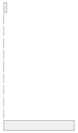

0  
(0.0%)

fallec  
[labelled, factor]

Durante su hospitalización, ¿el paciente falleció?

1. Sí (historia lo indica)  
2. No (historia lo indica)  
3. Información no disponible

869 (65.5%)  
456 (34.4%)  
2 ( 0.2%)

76  
(5.4%)

fallec_fecha  
[labelled, character]

Fecha de fallecimiento

1. (Empty string)  
2. 2020-05-29  
3. 2021-01-19  
4. 2021-02-12  
5. 2020-05-24  
6. 2020-06-05  
7. 2021-02-27  
8. 2020-05-04  
9. 2021-02-02  
10. 2020-05-20  
[ 221 others ]

534 (38.1%)  
16 ( 1.1%)  
14 ( 1.0%)  
14 ( 1.0%)  
13 ( 0.9%)  
13 ( 0.9%)  
13 ( 0.9%)  
12 ( 0.9%)  
12 ( 0.9%)  
11 ( 0.8%)  
751 (53.5%)

0  
(0.0%)

fallec_hora  
[labelled, character]

Hora de fallecimiento

1. (Empty string)  
2. 15:40  
3. 23:12  
4. 09:50  
5. 16:40  
6. 05:57  
7. 16:04  
8. 11:00  
9. 15:30  
10. 18:00  
[ 513 others ]

534 (38.1%)  
15 ( 1.1%)  
13 ( 0.9%)  
12 ( 0.9%)  
8 ( 0.6%)  
7 ( 0.5%)  
7 ( 0.5%)  
6 ( 0.4%)  
6 ( 0.4%)  
6 ( 0.4%)  
789 (56.2%)

0  
(0.0%)

fallec_causa  
[labelled, character]

Causa muerte - enfermedad que produjo muerte directamente

1. (Empty string)  
2. PARO CARDIORESPIRATORIO  
3. INSUFICIENCIA RESPIRATORI  
4. Paro cardiorrespiratorio  
5. INSUFICIENCIA RESPIRATORI  
6. INSUFICIENCIA RESPIRATORI  
7. Insuficiencia respiratori  
8. Insuficiencia respiratori  
9. insuficiencia respiratori  
10. INSUFICIENCIA RESPIRATORI  
[ 103 others ]

534 (38.1%)  
101 ( 7.2%)  
99 ( 7.1%)  
80 ( 5.7%)  
61 ( 4.3%)  
58 ( 4.1%)  
51 ( 3.6%)  
46 ( 3.3%)  
30 ( 2.1%)  
27 ( 1.9%)  
316 (22.5%)

0  
(0.0%)

fallec_relaccovid  
[labelled, factor]

¿Muerte relacionada a COVID-19?

1. Sí (historia lo indica)  
2. No (historia lo indica)  
3. Información no disponible

847 (97.5%)  
19 ( 2.2%)  
3 ( 0.3%)

534  
(38.1%)

fallec_lugar  
[labelled, factor]

Lugar donde el paciente falleció

1. Hospitalización/Emergenci  
2. UCI HNERM  
3. Otro hospital o centros d  
4. Hogar  
5. Información no disponible

707 (81.4%)  
160 (18.4%)  
1 ( 0.1%)  
0 ( 0.0%)  
1 ( 0.1%)

534  
(38.1%)

alta  
[labelled, factor]

¿El paciente fue dado de alta?

1. Sí  
2. No  
3. Información no disponible

370 (27.9%)  
932 (70.3%)  
24 ( 1.8%)

77  
(5.5%)

alta_fecha  
[labelled, character]

Fecha cuando el paciente fue dado de alta

1. (Empty string)  
2. 2021-01-08  
3. 2021-02-24  
4. 2021-01-16  
5. 2021-02-08  
6. 2021-02-10  
7. 2021-03-05  
8. 2020-05-26  
9. 2020-12-18  
10. 2020-12-24  
[ 215 others ]

1033 (73.6%)  
7 ( 0.5%)  
6 ( 0.4%)  
5 ( 0.4%)  
5 ( 0.4%)  
5 ( 0.4%)  
5 ( 0.4%)  
4 ( 0.3%)  
4 ( 0.3%)  
4 ( 0.3%)  
325 (23.2%)

0  
(0.0%)

alta_hora  
[labelled, character]

Hora cuando el paciente fue dado de alta (Consignar hora consignada en el registro electrónico)

1. (Empty string)  
2. 12:00  
3. 18:01  
4. 11:00  
5. 18:57  
6. 09:47  
7. 12:36  
8. 10:44  
9. 11:55  
10. 12:40  
[ 226 others ]

1033 (73.6%)  
14 ( 1.0%)  
10 ( 0.7%)  
9 ( 0.6%)  
9 ( 0.6%)  
7 ( 0.5%)  
7 ( 0.5%)  
6 ( 0.4%)  
4 ( 0.3%)  
4 ( 0.3%)  
300 (21.4%)

0  
(0.0%)

alta_motivo  
[labelled, factor]

Motivo de alta

1. Curación o Mejoría  
2. Transferencia a otro esta  
3. Alta voluntaria  
4. Información no disponible

346 (93.5%)  
12 ( 3.2%)  
7 ( 1.9%)  
5 ( 1.4%)

1033  
(73.6%)

vmi_crit  
[labelled, factor]

¿Participante cumplió criterio de VMI en algun momento de su hospitalización?

1. Sí (historia lo indica)  
2. No (historia lo indica)  
3. Información no disponible

1169 (88.0%)  
140 (10.5%)  
19 ( 1.4%)

75  
(5.3%)

vmi_crit_cualcrit  
[labelled, character]

Detallar criterios para necesidad de VMI

1. (Empty string)  
2. Disnea  
3. PO2/FiO2 < 200  
4. pafi<200  
5. Insuficiencia respiratori  
6. pafi<200 evolucion torpi  
7. pafi<200 compromiso neur  
8. Disnea moderada o severa  
9. compromiso neurologico  
10. Disne  
[ 669 others ]

234 (16.7%)  
147 (10.5%)  
126 ( 9.0%)  
102 ( 7.3%)  
15 ( 1.1%)  
11 ( 0.8%)  
8 ( 0.6%)  
7 ( 0.5%)  
6 ( 0.4%)  
4 ( 0.3%)  
743 (53.0%)

0  
(0.0%)

vmi_crit_fecha  
[labelled, character]

¿Cuándo cumplió criterio para VMI por primera vez? - Fecha

1. (Empty string)  
2. 2020-05-30  
3. 2021-01-31  
4. 2021-02-16  
5. 2021-02-23  
6. 2020-05-15  
7. 2020-05-19  
8. 2020-05-26  
9. 2021-01-18  
10. 2021-01-30  
[ 243 others ]

234 (16.7%)  
14 ( 1.0%)  
14 ( 1.0%)  
14 ( 1.0%)  
14 ( 1.0%)  
13 ( 0.9%)  
13 ( 0.9%)  
13 ( 0.9%)  
13 ( 0.9%)  
13 ( 0.9%)  
1048 (74.7%)

0  
(0.0%)

vmi_crit_hora  
[labelled, character]

¿Cuándo cumplió criterio para VMI por primera vez? - Hora

1. (Empty string)  
2. 12:27  
3. 16:17  
4. 22:17  
5. 23:07  
6. 04:33  
7. 22:00  
8. 06:33  
9. 18:18  
10. 23:20  
[ 736 others ]

234 (16.7%)  
9 ( 0.6%)  
9 ( 0.6%)  
9 ( 0.6%)  
8 ( 0.6%)  
6 ( 0.4%)  
6 ( 0.4%)  
5 ( 0.4%)  
5 ( 0.4%)  
5 ( 0.4%)  
1107 (78.9%)

0  
(0.0%)

vmi  
[labelled, factor]

¿El paciente inició VMI?

1. Sí (historia lo indica)  
2. No (historia lo indica)  
3. Información no disponible

818 (61.6%)  
491 (37.0%)  
19 ( 1.4%)

75  
(5.3%)

vmi_fecha  
[labelled, character]

¿Cuándo inició VMI? - Fecha

1. (Empty string)  
2. 2021-02-23  
3. 2021-01-18  
4. 2021-02-09  
5. 2021-01-03  
6. 2021-01-19  
7. 2021-01-21  
8. 2021-02-11  
9. 2021-02-18  
10. 2020-05-21  
[ 223 others ]

585 (41.7%)  
13 ( 0.9%)  
11 ( 0.8%)  
10 ( 0.7%)  
9 ( 0.6%)  
9 ( 0.6%)  
9 ( 0.6%)  
9 ( 0.6%)  
9 ( 0.6%)  
8 ( 0.6%)  
731 (52.1%)

0  
(0.0%)

vmi_hora  
[labelled, character]

¿Cuándo inició VMI? - Hora

1. (Empty string)  
2. 09:43  
3. 16:48  
4. 11:43  
5. 18:20  
6. 02:12  
7. 10:00  
8. 16:31  
9. NI  
10. 01:52  
[ 557 others ]

585 (41.7%)  
9 ( 0.6%)  
8 ( 0.6%)  
7 ( 0.5%)  
7 ( 0.5%)  
5 ( 0.4%)  
5 ( 0.4%)  
5 ( 0.4%)  
5 ( 0.4%)  
4 ( 0.3%)  
763 (54.4%)

0  
(0.0%)

desenlaces_de_estudio_complete  
[labelled, factor]

Complete?

1. Incomplete  
2. Unverified  
3. Complete

0 ( 0.0%)  
0 ( 0.0%)  
1403 (100.0%)

0  
(0.0%)

## 3 Preparación de datos

**Código**

```r
## Cleaning of variables for predictive scores
data <-
  data_raw %>%
  ### ISARIC-4C----
  mutate(
    #### Fecha de ingreso----
    fecha_admin = date(ymd_hm(emerg_admin_fecha)),

    ### Criterios de elegibilidad----

    ### Otras caracteristicas relevantes----


    #### Age----
    agecat = case_when(
      edad < 50 ~ "<50",
      edad >= 50 & edad < 60 ~ "50-59",
      edad >= 60 & edad < 70 ~ "60-69",
      edad >= 70 & edad < 80 ~ "70-79",
      edad >= 80 ~ ">=80",
      TRUE ~ as.character(NA)
    ),
    agecat = factor(agecat,
                    levels = c("<50", "50-59", "60-69", "70-79", ">=80")),
    score4c_age = case_when(
      edad < 50 ~ 0L,
      edad >= 50 & edad < 60 ~ 2L,
      edad >= 60 & edad < 70 ~ 4L,
      edad >= 70 & edad < 80 ~ 6L,
      edad >= 80 ~ 7L,
      TRUE ~ as.integer(NA)
    ),

    #### Sex at birth----
    sex = case_when(
      sexo == "Femenino" ~ "Female",
      sexo == "Masculino" ~ "Male",
      TRUE ~ as.character(NA)
    ),
    score4c_sex = case_when(
      sexo == "Femenino" ~ 0L,
      sexo == "Masculino" ~ 1L,
      TRUE ~ as.integer(NA)
    ),

    #### Number of comorbidities----
    across(c(com_fcc, com_im, com_epoc, com_er, com_erc_modsev, com_hepa_leve,
           com_hepa_modsev, com_demen, com_ecv, com_tia, com_hemip, com_etc,
           com_dmnc, com_dmc, com_sida, inm_vih, com_tsol_loc, com_tsol_met,
           com_leuc, com_linf, obesidad_sino), ~ recode_factor(.,
                                                        "No (historia lo indica)" = "No",
                                                        "Información no disponible en la historia" = "No",
                                                        "Sí (historia lo indica)" = "Yes")),
    across(c(com_fcc, com_im, com_epoc, com_er, com_erc_modsev, com_hepa_leve,
           com_hepa_modsev, com_demen, com_ecv, com_tia, com_hemip, com_etc,
           com_dmnc, com_dmc, com_sida, inm_vih, com_tsol_loc, com_tsol_met,
           com_leuc, com_linf, obesidad_sino), ~ as.integer(.) - 1),
    ncomorb1 = com_fcc + com_im + com_epoc + com_er + com_erc_modsev +
      com_hepa_leve + com_hepa_modsev + com_demen + com_ecv, com_tia +
      com_hemip + com_etc + com_dmnc + com_dmc + com_sida + inm_vih +
      com_tsol_loc + com_tsol_met + com_leuc + com_linf + obesidad_sino,
    ncomorb2 = com_fcc + com_im + com_epoc + com_erc_modsev +
      com_hepa_leve + com_hepa_modsev + com_demen + com_ecv, com_tia +
      com_hemip + com_etc + com_dmnc + com_dmc + com_sida + inm_vih +
      com_tsol_loc + com_tsol_met + com_leuc + com_linf + obesidad_sino,
    ncomorb1cat = case_when(
      ncomorb1 == 0 ~ "0",
      ncomorb1 == 1 ~ "1",
      ncomorb1 >= 2 ~ ">=2",
      TRUE ~ as.character(NA)
    ),
    score4c_ncomorb1 = case_when(
      ncomorb1 == 0 ~ 0L,
      ncomorb1 == 1 ~ 1L,
      ncomorb1 >= 2 ~ 2L,
      TRUE ~ as.integer(NA)
    ),
   ncomorb2cat = case_when(
      ncomorb2 == 0 ~ "0",
      ncomorb2 == 1 ~ "1",
      ncomorb2 >= 2 ~ ">=2",
      TRUE ~ as.character(NA)
    ),
    score4c_ncomorb2 = case_when(
      ncomorb2 == 0 ~ 0L,
      ncomorb2 == 1 ~ 1L,
      ncomorb2 >= 2 ~ 2L,
      TRUE ~ as.integer(NA)
    ),
    across(c(ncomorb1cat, ncomorb2cat), ~ factor(., levels = c("0", "1", ">=2"))),

   #### Respiratory rate----
   rr = case_when(
     sv_fr_res < 20 ~ "<20",
     sv_fr_res >= 20 & sv_fr_res < 30 ~ "20-29",
     sv_fr_res >= 30  ~ ">=30"
   ),
   rr = factor(rr, levels = c("<20", "20-29", ">=30")),
   score_4c_rr = case_when(
     sv_fr_res < 20 ~ 0L,
     sv_fr_res >= 20 & sv_fr_res < 30 ~ 1L,
     sv_fr_res >= 30  ~ 2L,
     TRUE ~ as.integer(NA)
   ),

   #### Peripheral oxygen saturation----
   across(c(sv_satodisp_res, sv_satoamb_res), ~ na_if(., "NI")),
   across(c(sv_satodisp_res, sv_satoamb_res), ~ na_if(., "")),
   across(c(sv_satodisp_res, sv_satoamb_res), ~ as.numeric(.)),
   sv_satoamb_res = replace(sv_satoamb_res, sv_satoamb_res == 0.8, 80),
   sato1 = case_when(
     sv_satoamb_res >= 92 ~ ">=92",
     sv_satoamb_res < 92 ~ "<92",
     TRUE ~ as.character(NA)
   ),
   score4c_sato1 = case_when(
     sv_satoamb_res >= 92 ~ 0L,
     sv_satoamb_res < 92 ~ 2L,
     TRUE ~ as.integer(NA)
   ),
   sato2 = case_when(
     sv_satoamb_res >= 92 ~ ">=92",
     sv_satoamb_res < 92 | (sv_satodisp_res < 92 & is.na(sv_satoamb_res)) |
       (oxigen_tipo %in% c("Cánula simple", "Mascarilla simple",
                           "Mascarilla venturi", "Mascarilla de reservorio",
                           "Cánula nasal simple + mascarilla de reservorio",
                           "Cánula de Alto Flujo",
                           "Ventilador mecánico") & is.na(sv_satoamb_res)) ~ "<92",
        TRUE ~ as.character(NA)
   ),
   score4c_sato2 = case_when(
     sv_satoamb_res >= 92 ~ 0L,
     sv_satoamb_res < 92 | (sv_satodisp_res < 92 & is.na(sv_satoamb_res)) |
       (oxigen_tipo %in% c("Cánula simple", "Mascarilla simple",
                           "Mascarilla venturi", "Mascarilla de reservorio",
                           "Cánula nasal simple + mascarilla de reservorio",
                           "Cánula de Alto Flujo",
                           "Ventilador mecánico") & is.na(sv_satoamb_res))  ~ 2L,
     TRUE ~ as.integer(NA)
     ),
  across(c(sato1, sato2), ~ factor(., levels = c(">=92", "<92"))),

   #### Glasgow coma scale - proxy by confusion an altered mental status----
   coma1 = case_when(
     sint_confusion %in% c("No (historia lo indica)",
                           "Información no disponible en la historia") ~ "15",
     sint_confusion == "Sí (historia lo indica)" ~ "<15",
     TRUE ~ as.character(NA)
   ),
   score4c_coma1 = case_when(
     sint_confusion %in% c("No (historia lo indica)",
                           "Información no disponible en la historia") ~ 0L,
     sint_confusion == "Sí (historia lo indica)" ~ 2L,
     TRUE ~ as.integer(NA)
   ),
  coma2 = case_when(
     (sint_confusion %in% c("No (historia lo indica)",
                           "Información no disponible en la historia") &
       alter_mental %in% c("No (historia lo indica)",
                           "Información no disponible en la historia")) |
       (sint_confusion %in% c("No (historia lo indica)",
                           "Información no disponible en la historia") &
       is.na(alter_mental)) |
       (is.na(sint_confusion) & alter_mental %in%
          c("No (historia lo indica)",
            "Información no disponible en la historia")) ~ "15",
     sint_confusion == "Sí (historia lo indica)" | alter_mental == "Sí (historia lo indica)" ~ "<15",
     TRUE ~ as.character(NA)
   ),
   score4c_coma2 = case_when(
     (sint_confusion %in% c("No (historia lo indica)",
                           "Información no disponible en la historia") &
       alter_mental %in% c("No (historia lo indica)",
                           "Información no disponible en la historia")) |
       (sint_confusion %in% c("No (historia lo indica)",
                           "Información no disponible en la historia") &
       is.na(alter_mental)) |
       (is.na(sint_confusion) & alter_mental %in%
          c("No (historia lo indica)",
            "Información no disponible en la historia")) ~ 0L,
     sint_confusion == "Sí (historia lo indica)" | alter_mental == "Sí (historia lo indica)" ~ 2L,
     TRUE ~ as.integer(NA)
   ),
  across(c(coma1, coma2), ~ factor(., levels = c("15", "<15"))),

  #### Urea original (mg/dL)----
  urea = lab_res_urea * 0.357/2.1428, #< Convierte mg/dL a mmol/L
  ureacat = case_when(
    urea < 7 ~ "<7",
    urea >= 7 & urea <= 14 ~ "7-14",
    urea > 14 ~ ">14",
    TRUE ~ as.character(NA)
  ),
  ureacat = factor(ureacat, levels = c("<7", "7-14", ">14")),
  score4c_urea = case_when(
    urea < 7 ~ 0L,
    urea >= 7 & urea <= 14 ~ 1L,
    urea > 14 ~ 3L,
    TRUE ~ as.integer(NA)
  ),

   #### C reactive protein original (mg/dL)----
  pcr = lab_res_pcr,
  pcrcat = case_when(
    pcr < 5 ~ "<5",
    pcr >= 5 & pcr < 10 ~ "5-9.9",
    pcr >= 10 ~ ">= 10",
    TRUE ~ as.character(NA)
  ),
  pcrcat = factor(pcrcat, levels = c("<5", "5-9.9", ">= 10")),
  score4c_pcr = case_when(
    pcr < 5 ~ 0L,
    pcr >= 5 & pcr < 10 ~ 1L,
    pcr >= 10 ~ 2L,
    TRUE ~ as.integer(NA)
  ),
  #### Puntaje ISARIC4C----
  score4c = score4c_age +  score4c_sex + score4c_ncomorb2 + score_4c_rr + score4c_sato2 + score4c_coma2 + score4c_urea + score4c_pcr,
score4c_gr = factor(case_when(
    score4c <= 3 ~ "Low (0-3)",
    score4c >= 4 & score4c <= 8 ~ "Intermediate (4-8)",
    score4c >= 9 & score4c <= 14 ~ "High (9-14)",
    score4c >= 15 ~ "Very high (>= 15)",
    TRUE ~ as.character(NA)
  ), level = c("Low (0-3)", "Intermediate (4-8)", "High (9-14)", "Very high (>= 15)")),
  death = case_when(
    fallec %in% c("No (historia lo indica)") ~ "Alive",
    fallec == "Sí (historia lo indica)" ~ "Death",
    TRUE ~ as.character(NA)
  ),
  death2 = case_when(
    fallec %in% c("No (historia lo indica)") ~ 0,
    fallec == "Sí (historia lo indica)" ~ 1,
    TRUE ~ as.numeric(NA)
  ),
  score4c_risk = case_when(
    score4c_gr == "Low (0-3)" ~ 1.2,
    score4c_gr == "Intermediate (4-8)" ~ 9.9,
    score4c_gr == "High (9-14)" ~ 31.4,
    score4c_gr == "Very high (>= 15)" ~ 61.5
    )
  ) %>%
  set_variable_labels(
    sexo = "Sexo",
    edad = "Edad (años)",
    agecat = "Grupo etario",
    ncomorb2 = "Número de comorbilidades",
    ncomorb2cat = "Número de comorbilidades",
    com_fcc = "Falla cardíaca congestiva",
    com_im = "Antecedente de infarto agudo a miocardio",
    com_epoc = "Enfermedad pulmonar obstructiva crónica",
    com_er = "Enfermedad renal crónica ",
    com_erc_modsev = "Enfermedad renal crónica - moderada a severa",
    com_hepa_leve = "Enfermedad hepática leve",
    com_hepa_modsev = "Enfermedad hepática severa",
    com_demen = "Demencia",
    com_ecv = "Enfermedad cerebrovascular",
    com_tia = "Accidente isquémico transitorio",
    com_hemip = "Hemiplejía",
    com_etc = "Emfermedad del tejido conectivo",
    com_dmnc = "Diabetes mellitus no complicada",
    com_dmc = "Diabetes mellitus complicada",
    com_sida = "SIDA",
    inm_vih = "VIH",
    com_tsol_loc = "Tumor sólido localizado",
    com_tsol_met = "Tumor sólido metastásico",
    com_leuc = "Leucemia",
    com_linf = "Linfoma",
    obesidad_sino = "Obesidad clínica",
    sv_fr_res = "Frecuencia respiratoria",
    rr = "Niveles de frecuencia respiratoria",
    sv_satoamb_res = "Saturación de Oxígeno con aire de ambiente",
    score4c_sato1 = "Niveles de saturación de Oxígeno con aire de ambiente",
    sato1 = "Niveles de saturación de Oxígeno con aire de ambiente",
    score4c_sato2 = "Niveles de saturación de Oxígeno con aire de ambiente y soporte de oxigeno",
    sato2 = "Niveles de saturación de Oxígeno con aire de ambiente y soporte de oxigeno",
    coma2 = "Nivel de conciencia",
    urea = "Úrea (mmol/L)",
    ureacat = "Niveles de urea (mmol/L)",
    pcr = "Proteína C reactiva (mg/dL)",
    pcrcat = "Niveles de Proteína C reactiva (mg/dL)",
    death = "Muerte"
  )
```

**Código**

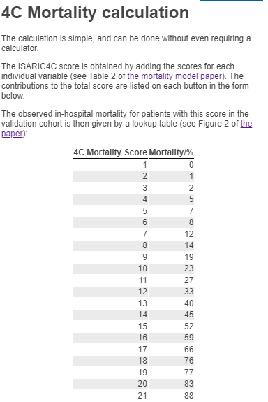

```r
knitr::include_graphics("images/4CScoreProbability.png")
```

Dar click en el siguiente [Enlace](https://isaric4c.net/risk/#:~:text=The%204C%20Mortality%20Score%20and,produced%20by%20the%20ISARIC4C%20consortium.) web para ir a la dirección web citada. También se usaron las probabilidades recalibradas en una evaluación prospectiva [Enlace](https://thorax.bmj.com/content/early/2021/11/21/thoraxjnl-2021-217629)

Se crea un data.frame con los puntajes y las probabilidades predichas del modelo original:

**Código**

```r
score4c_papers <- data.frame(
  score4c = 0:21,
  risk_pred_web = c(0, 0, 1, 2, 5, 7, 8, 12, 14, 19, 23, 27, 33, 40, 45, 52, 59, 66, 76, 77, 83, 88) / 100,  #< Ver enlace web
  risk_pred_orig = c(0, 0.3, 0.8, 2.3, 4.8, 7.5, 7.8, 11.7, 14.4, 19.2, 22.9, 26.9, 32.9, 40.1, 44.6, 51.6, 59.1, 66.1, 75.8, 77.3, 82.9, 87.5) / 100, # ver prospective validation
  risk_pred_recal = c(0.4, 0.9, 1.3, 2.5, 4.0, 5.8, 8.7, 10.5, 14.5, 19.9, 25.3, 31.2, 37.7, 44.7, 51.3, 57.3, 64.0, 68.7, 77.6, 79.6, 87.3, 96.1) / 100
)

score4c_papers %>%
  kbl() %>%
  kable_styling()
```

| score4c | risk_pred_web | risk_pred_orig | risk_pred_recal |
| --- | --- | --- | --- |
| 0 | 0.00 | 0.000 | 0.004 |
| 1 | 0.00 | 0.003 | 0.009 |
| 2 | 0.01 | 0.008 | 0.013 |
| 3 | 0.02 | 0.023 | 0.025 |
| 4 | 0.05 | 0.048 | 0.040 |
| 5 | 0.07 | 0.075 | 0.058 |
| 6 | 0.08 | 0.078 | 0.087 |
| 7 | 0.12 | 0.117 | 0.105 |
| 8 | 0.14 | 0.144 | 0.145 |
| 9 | 0.19 | 0.192 | 0.199 |
| 10 | 0.23 | 0.229 | 0.253 |
| 11 | 0.27 | 0.269 | 0.312 |
| 12 | 0.33 | 0.329 | 0.377 |
| 13 | 0.40 | 0.401 | 0.447 |
| 14 | 0.45 | 0.446 | 0.513 |
| 15 | 0.52 | 0.516 | 0.573 |
| 16 | 0.59 | 0.591 | 0.640 |
| 17 | 0.66 | 0.661 | 0.687 |
| 18 | 0.76 | 0.758 | 0.776 |
| 19 | 0.77 | 0.773 | 0.796 |
| 20 | 0.83 | 0.829 | 0.873 |
| 21 | 0.88 | 0.875 | 0.961 |

**Código**

```r
data2 <-
  data %>%
  left_join(score4c_papers, by = "score4c")

data2 %>%
  glimpse()
```

```
Rows: 1,403
Columns: 231
$ record_id                      <labelled> "1", "2", "4", "5", "6", "7", "8",…
$ redcap_data_access_group       <fct> acceso16, acceso16, acceso16, acceso16,…
$ recolect_id                    <labelled> "garomeroc", "garomeroc", "garomer…
$ fecha_llenado                  <labelled> "2021-12-29 09:51:13", "2021-12-29…
$ doc_tipo_otros                 <labelled> NA, NA, NA, NA, NA, NA, NA, NA, NA…
$ sexo                           <fct> Femenino, Masculino, Masculino, Femenin…
$ edad                           <labelled> 66, 69, 36, 81, 80, 77, 71, 79, 56…
$ sint_resp                      <fct> Sí (historia lo indica), Sí (historia l…
$ dx_covid_pcr                   <fct> Negativo (cuenta con prueba o evaluació…
$ dx_covid_pantig                <fct> No cuenta  con prueba o evaluación, No …
$ dx_covid_prapid                <fct> Negativo (cuenta con prueba o evaluació…
$ dx_covid_clintac               <fct> Positivo (cuenta con prueba o evaluació…
$ emerg_admin                    <fct> Sí, Sí, Sí, Sí, Sí, Sí, Sí, Sí, Sí, Sí,…
```

[output cut: 218 more lines]

## 4 Guardar tabla de datos limpia

**Código**

```r
saveRDS(data2, paste0(here::here(), "/Data/Tidy/isaric_data.rds"))
```